# data census gov demographic per state additions

Janis Corona

8/10/2020

This script is exactly, more or less, like the same file that used 3 most populated state cities, but this time we use the 10 most populated cities in each states. We gathered race demographics and median pay from data.census.gov for 2018 data that was the closest to this year’s date of 2020, yellowpages.com, Indeed.com, apartments.com data using webscrape scripts and Zillows’s research data for friendly sharing without webscraping. The two bedroom and two bath apartments were from aparments.com and we used multifamily home median values per city from Zillow data.

All webscrapes took only the first five pages of those listings. Later scripts had each iteration stop by uploading and writing the data after each of 500 iterations done in batches of 10-25 so that we could ethically grab the online data without tying up their servers. Because apartments.com (also rent.com) and yellowpages.com didn’t like that at all. Sometimes Indeed would boot the script off too. I even used a VPN to mix the IP shelling out $13/month but they knew the pattern of cities, and it got ugly when I tried to rearrange the batches. This could have gotten completed in less than a day, but because of the constant restarting of the computer or VPN and waiting to grab each of 500 city data on 20 Indeed jobs and 9 yellowpages businesses and 500 city’s first five pages of apartment listings, this took about two days.

All files are in the github repository located at https://github.com/JanJanJan2018/LMT-State-Licensing-Database and the census data that we start adding to this table is pulled from 2018 data from Data.census.gov demographics to add per state to state licensing requirements excel file: https://data.census.gov/cedsci/table?q=median%20pay%20by%20region%20and%20race&tid=ACSDP1Y2018.DP05&vintage=2018&cid=DP05_0001E&g=0100000US.04000.001&hidePreview=false

```r
library(ggplot2)
library(grid)
library(gridExtra)
library(dplyr)
library(tidyr)
```

```r
data <- read.csv('ACSDP1Y2018.DP05_data_with_overlays_2020-07-07T154725.csv',
                 sep=',',
                 header=TRUE, na.strings = c('',' ','NA'))

meta <- read.csv('ACSDP1Y2018.DP05_metadata_2020-07-07T154725.csv',header=TRUE,
                 sep=',',na.strings=c('',' ','NA'))
```

```r
head(data)
```

```
##        GEO_ID                 NAME                              DP05_0001E
## 1          id Geographic Area Name Estimate!!SEX AND AGE!!Total population
## 2 0400000US17             Illinois                                12741080
## 3 0400000US19                 Iowa                                 3156145
## 4 0400000US29             Missouri                                 6126452
## 5 0400000US32               Nevada                                 3034392
## 6 0400000US42         Pennsylvania                                12807060
##                                       DP05_0001M
## 1 Margin of Error!!SEX AND AGE!!Total population
## 2                                          *****
## 3                                          *****
## 4                                          *****
## 5                                          *****
## 6                                          *****
##                                       DP05_0001PE
```

[output cut: 2463 more lines]

```r
meta <- meta[,-3]
head(meta)
```

```
##        GEO_ID                                                     id
## 1        NAME                                   Geographic Area Name
## 2  DP05_0001E                Estimate!!SEX AND AGE!!Total population
## 3  DP05_0001M         Margin of Error!!SEX AND AGE!!Total population
## 4 DP05_0001PE        Percent Estimate!!SEX AND AGE!!Total population
## 5 DP05_0001PM Percent Margin of Error!!SEX AND AGE!!Total population
## 6  DP05_0002E          Estimate!!SEX AND AGE!!Total population!!Male
```

```r
df <- data[-c(1,21,40),-1]
row.names(df) <- NULL
df$NAME <- as.character(paste(df$NAME))
```

```r
metanames <- meta$GEO_ID
dfnames <- as.factor(colnames(df))
```

```r
length(metanames)==length(dfnames)
```

```
## [1] TRUE
```

```r
g <- metanames==dfnames
sum(g==TRUE)
```

```
## [1] 357
```

```r
meta$id <- as.character(paste(meta$id))

err <- grep('Error',meta$id)

DF <- df[,-err]
```

```r
head(DF)
```

```
##           NAME DP05_0001E DP05_0001PE DP05_0002E DP05_0002PE DP05_0003E
## 1     Illinois   12741080    12741080    6266062        49.2    6475018
## 2         Iowa    3156145     3156145    1564888        49.6    1591257
## 3     Missouri    6126452     6126452    3003165        49.0    3123287
## 4       Nevada    3034392     3034392    1522374        50.2    1512018
## 5 Pennsylvania   12807060    12807060    6271620        49.0    6535440
## 6         Utah    3161105     3161105    1592457        50.4    1568648
##   DP05_0003PE DP05_0004E DP05_0004PE DP05_0005E DP05_0005PE DP05_0006E
## 1        50.8       96.8         (X)     759456         6.0     762237
## 2        50.4       98.3         (X)     197883         6.3     197454
## 3        51.0       96.2         (X)     370408         6.0     373737
## 4        49.8      100.7         (X)     184539         6.1     188880
## 5        51.0       96.0         (X)     700416         5.5     708163
## 6        49.6      101.5         (X)     250194         7.9     257110
##   DP05_0006PE DP05_0007E DP05_0007PE DP05_0008E DP05_0008PE DP05_0009E
```

[output cut: 195 more lines]

```r
estimate <- grep('Estimate',meta$id)

Estimate <- meta[estimate,]
head(Estimate)
```

```
##         GEO_ID                                                      id
## 2   DP05_0001E                 Estimate!!SEX AND AGE!!Total population
## 4  DP05_0001PE         Percent Estimate!!SEX AND AGE!!Total population
## 6   DP05_0002E           Estimate!!SEX AND AGE!!Total population!!Male
## 8  DP05_0002PE   Percent Estimate!!SEX AND AGE!!Total population!!Male
## 10  DP05_0003E         Estimate!!SEX AND AGE!!Total population!!Female
## 12 DP05_0003PE Percent Estimate!!SEX AND AGE!!Total population!!Female
```

```r
age <- Estimate[grep('AGE',Estimate$id),]
head(age)
```

```
##         GEO_ID                                                      id
## 2   DP05_0001E                 Estimate!!SEX AND AGE!!Total population
## 4  DP05_0001PE         Percent Estimate!!SEX AND AGE!!Total population
## 6   DP05_0002E           Estimate!!SEX AND AGE!!Total population!!Male
## 8  DP05_0002PE   Percent Estimate!!SEX AND AGE!!Total population!!Male
## 10  DP05_0003E         Estimate!!SEX AND AGE!!Total population!!Female
## 12 DP05_0003PE Percent Estimate!!SEX AND AGE!!Total population!!Female
```

```r
race <- Estimate[grep('RACE',Estimate$id),]
head(race)
```

```
##          GEO_ID                                                          id
## 130  DP05_0033E                            Estimate!!RACE!!Total population
## 132 DP05_0033PE                    Percent Estimate!!RACE!!Total population
## 134  DP05_0034E                  Estimate!!RACE!!Total population!!One race
## 136 DP05_0034PE          Percent Estimate!!RACE!!Total population!!One race
## 138  DP05_0035E         Estimate!!RACE!!Total population!!Two or more races
## 140 DP05_0035PE Percent Estimate!!RACE!!Total population!!Two or more races
```

```r
percentRace <- race[grep('Percent',race$id),]
percentRace$id <- gsub('Percent Estimate!!RACE!!','',percentRace$id)
percentRace
```

```
##          GEO_ID
## 132 DP05_0033PE
## 136 DP05_0034PE
## 140 DP05_0035PE
## 144 DP05_0036PE
## 148 DP05_0037PE
## 152 DP05_0038PE
## 156 DP05_0039PE
## 160 DP05_0040PE
## 164 DP05_0041PE
## 168 DP05_0042PE
## 172 DP05_0043PE
## 176 DP05_0044PE
## 180 DP05_0045PE
## 184 DP05_0046PE
```

[output cut: 79 more lines]

Lets get the white, black, asian, native american indian, two or more total, pacific islander, and latino groups.

```r
totalPop <- percentRace[1,]
black <- percentRace[6,]
white <- percentRace[5,]
twoOrMore <- percentRace[3,]
AmericanIndian <- percentRace[7,]
Asian <- percentRace[12,]
pacificIslander <- percentRace[20,]
LatinoHispanic <- percentRace[32,]

totalPop$id <- 'total_state_population'
black$id <- 'percent_black'
white$id <- 'percent_white'
twoOrMore$id <- 'percent_two_or_more'
AmericanIndian$id <- 'percent_Native_American'
Asian$id <- 'percent_Asian'
pacificIslander$id <- 'percent_Pacific_Islander'
LatinoHispanic$id <- 'percent_Latino'

EthnicBackground <- rbind(totalPop,black,white,twoOrMore,AmericanIndian,Asian,pacificIslander,LatinoHispanic)
EthnicBackground
```

```
##          GEO_ID                       id
## 132 DP05_0033PE   total_state_population
## 152 DP05_0038PE            percent_black
## 148 DP05_0037PE            percent_white
## 140 DP05_0035PE      percent_two_or_more
## 156 DP05_0039PE  percent_Native_American
## 176 DP05_0044PE            percent_Asian
## 208 DP05_0052PE percent_Pacific_Islander
## 284 DP05_0071PE           percent_Latino
```

```r
IDs <- EthnicBackground$GEO_ID
class(IDs)
```

```
## [1] "factor"
```

```r
IDs <- as.character(paste(IDs))
```

```r
DF2 <- DF[,c('NAME',IDs)]
DF2
```

```
##              NAME DP05_0033PE DP05_0038PE DP05_0037PE DP05_0035PE DP05_0039PE
## 1        Illinois    12741080        14.1        71.7         2.7         0.3
## 2            Iowa     3156145         3.6        90.2         2.2         0.4
## 3        Missouri     6126452        11.5        82.2         2.8         0.5
## 4          Nevada     3034392         9.2        63.4         5.1         1.5
## 5    Pennsylvania    12807060        11.2        80.1         2.6         0.2
## 6            Utah     3161105         1.3        85.7         3.2         1.1
## 7   West Virginia     1805832         3.8        93.0         1.9         0.1
## 8        Colorado     5695564         4.2        84.1         4.0         1.0
## 9         Georgia    10519475        31.6        58.3         2.7         0.3
## 10          Idaho     1754208         0.7        89.9         3.0         1.3
## 11       Maryland     6042718        30.0        54.7         3.7         0.2
## 12     New Jersey     8908520        13.6        66.9         2.8         0.2
## 13     New Mexico     2095428         2.2        76.4         3.2         9.6
## 14           Ohio    11689442        12.4        81.0         3.1         0.2
```

[output cut: 87 more lines]

```r
colnames(DF2) <- c('state',EthnicBackground$id)
DF2
```

```
##             state total_state_population percent_black percent_white
## 1        Illinois               12741080          14.1          71.7
## 2            Iowa                3156145           3.6          90.2
## 3        Missouri                6126452          11.5          82.2
## 4          Nevada                3034392           9.2          63.4
## 5    Pennsylvania               12807060          11.2          80.1
## 6            Utah                3161105           1.3          85.7
## 7   West Virginia                1805832           3.8          93.0
## 8        Colorado                5695564           4.2          84.1
## 9         Georgia               10519475          31.6          58.3
## 10          Idaho                1754208           0.7          89.9
## 11       Maryland                6042718          30.0          54.7
## 12     New Jersey                8908520          13.6          66.9
## 13     New Mexico                2095428           2.2          76.4
## 14           Ohio               11689442          12.4          81.0
```

[output cut: 138 more lines]

```r
Ethnicities <- DF2[order(DF2$state),]
row.names(Ethnicities) <- NULL
Ethnicities
```

```
##             state total_state_population percent_black percent_white
## 1         Alabama                4887871          26.7          67.7
## 2          Alaska                 737438           3.4          64.4
## 3         Arizona                7171646           4.7          78.0
## 4        Arkansas                3013825          15.2          76.5
## 5      California               39557045           5.8          59.5
## 6        Colorado                5695564           4.2          84.1
## 7     Connecticut                3572665          11.0          75.2
## 8        Delaware                 967171          22.5          68.2
## 9         Florida               21299325          16.0          74.6
## 10        Georgia               10519475          31.6          58.3
## 11         Hawaii                1420491           2.0          24.3
## 12          Idaho                1754208           0.7          89.9
## 13       Illinois               12741080          14.1          71.7
## 14        Indiana                6691878           9.5          82.8
```

[output cut: 138 more lines]

```r
write.csv(Ethnicities, 'race_distribution_2018.csv',row.names=FALSE)
```

Merge the state licensing excel file with this csv file to add in the demographic race data per state.

```r
stateREQs <- read.csv('stateLicensingRequirements.csv', sep=',', header=TRUE, na.strings=c('',' ','NA'))
```

```r
colnames(stateREQs)
```

```
##  [1] "state"
##  [2] "massageBoard"
##  [3] "licenseByReciprocity"
##  [4] "proofOtherOrAllStateLicense"
##  [5] "stateResidencyProof"
##  [6] "passportSizePhoto"
##  [7] "driversLicensePhotoCopy"
##  [8] "nameChangeProof"
##  [9] "socialSecurityCopy"
## [10] "Hours"
## [11] "MBLEX_or_NCBTMB"
## [12] "goodHealthClearance"
## [13] "BoardBackgroundCheckFee"
## [14] "stateApplyingBackgroundCheck"
## [15] "DOJ_backgroundCheck"
```

[output cut: 21 more lines]

```r
stateREQs <- stateREQs[,1:36]
colnames(stateREQs)
```

```
##  [1] "state"
##  [2] "massageBoard"
##  [3] "licenseByReciprocity"
##  [4] "proofOtherOrAllStateLicense"
##  [5] "stateResidencyProof"
##  [6] "passportSizePhoto"
##  [7] "driversLicensePhotoCopy"
##  [8] "nameChangeProof"
##  [9] "socialSecurityCopy"
## [10] "Hours"
## [11] "MBLEX_or_NCBTMB"
## [12] "goodHealthClearance"
## [13] "BoardBackgroundCheckFee"
## [14] "stateApplyingBackgroundCheck"
## [15] "DOJ_backgroundCheck"
```

[output cut: 21 more lines]

```r
Ethnicities$state <- as.factor(Ethnicities$state)
```

```r
StateLicensing <- merge(stateREQs,Ethnicities, by.x='state',by.y='state')
dim(StateLicensing)
```

```
## [1] 50 44
```

```r
colnames(StateLicensing)
```

```
##  [1] "state"
##  [2] "massageBoard"
##  [3] "licenseByReciprocity"
##  [4] "proofOtherOrAllStateLicense"
##  [5] "stateResidencyProof"
##  [6] "passportSizePhoto"
##  [7] "driversLicensePhotoCopy"
##  [8] "nameChangeProof"
##  [9] "socialSecurityCopy"
## [10] "Hours"
## [11] "MBLEX_or_NCBTMB"
## [12] "goodHealthClearance"
## [13] "BoardBackgroundCheckFee"
## [14] "stateApplyingBackgroundCheck"
## [15] "DOJ_backgroundCheck"
```

[output cut: 29 more lines]

We added the demographics to the state licensing requirements and facts csv version of the excel version.

Now lets add in the fields from our Indeed web scrape to update the columns 32-34 of the StateLicensing table.We added them in manually before, but now that a table was made with the copy of the indeed web scrape script that uses the modified writeIndeedJobData5Pages() using the original getIndeedJobData5Pages(). We can update the table on the fly as needed as long as the Indeed site doesn’t change its layout. This file is the statesRates.csv file made in the ‘copy-indeed-webscrape-function-altered.Rmd’ script.

```r
statesRates <- read.csv('./Indeed 10/jobListings_licensed massage therapist.csv', sep=',',header=TRUE, na.strings=c('',' ','NA'),
                       stringsAsFactors = FALSE)
head(statesRates)
```

```
##   state jobsListed                jobSearched MinHourlySalary MaxHourlySalary
## 1    ak        134 licensed massage therapist        29.07563        61.47059
## 2    al        123 licensed massage therapist        11.62903        55.32258
## 3    ar        231 licensed massage therapist        20.22124        22.22124
## 4    az        732 licensed massage therapist        13.28689        61.37978
## 5    ca        633 licensed massage therapist        15.87722        60.31664
## 6    co        708 licensed massage therapist        16.08121        60.10452
##   MinAnnualSalary MaxAnnualSalary avgHourly avgAnualSalary
## 1        75000.00       120000.00  45.27311       97500.00
## 2        30364.62        59264.36  33.47581       44814.49
## 3        35472.62        49083.38  21.22124       42278.00
## 4        38145.08       113835.45  37.33333       75990.27
## 5        44166.62       107445.95  38.09693       75806.28
## 6        25905.45       105501.60  38.09287       65703.53
```

```r
statesOrdered <- statesRates[order(statesRates$state),]
head(statesOrdered)
```

```
##   state jobsListed                jobSearched MinHourlySalary MaxHourlySalary
## 1    ak        134 licensed massage therapist        29.07563        61.47059
## 2    al        123 licensed massage therapist        11.62903        55.32258
## 3    ar        231 licensed massage therapist        20.22124        22.22124
## 4    az        732 licensed massage therapist        13.28689        61.37978
## 5    ca        633 licensed massage therapist        15.87722        60.31664
## 6    co        708 licensed massage therapist        16.08121        60.10452
##   MinAnnualSalary MaxAnnualSalary avgHourly avgAnualSalary
## 1        75000.00       120000.00  45.27311       97500.00
## 2        30364.62        59264.36  33.47581       44814.49
## 3        35472.62        49083.38  21.22124       42278.00
## 4        38145.08       113835.45  37.33333       75990.27
## 5        44166.62       107445.95  38.09693       75806.28
## 6        25905.45       105501.60  38.09287       65703.53
```

When ordering by the state abbreviations, the order isn’t the same as by the state spelled out. So lets compare the two and adjust changes.

```r
statesOrdered$state
```

```
##  [1] "ak" "al" "ar" "az" "ca" "co" "ct" "de" "fl" "ga" "hi" "ia" "id" "il" "in"
## [16] "ks" "ky" "la" "ma" "md" "me" "mi" "mn" "mo" "ms" "mt" "nc" "nd" "ne" "nh"
## [31] "nj" "nm" "nv" "ny" "oh" "ok" "or" "pa" "ri" "sc" "sd" "tn" "tx" "ut" "va"
## [46] "vt" "wa" "wi" "wv" "wy"
```

```r
statesOrdered <- statesOrdered[1:50,]
```

```r
states <- c("Alaska"  ,"Alabama"     ,      "Arkansas"     ,     "Arizona"     ,    "California",
 "Colorado"    ,   "Connecticut"  ,  "Delaware"     ,  "Florida"    ,    "Georgia"  ,
"Hawaii"   ,     "Iowa"   , "Idaho"   ,       "Illinois"  ,     "Indiana"        ,
 "Kansas"   ,      "Kentucky",       "Louisiana" ,  "Massachusetts",  "Maryland" , "Maine",
  "Michigan"  ,     "Minnesota"   ,  "Missouri"  , "Mississippi"    ,
"Montana"       , "North Carolina","North Dakota" ,"Nebraska"   ,  "New Hampshire" , "New Jersey", "New Mexico"     , "Nevada"       ,
"New York"    ,      "Ohio"       ,
"Oklahoma"      , "Oregon"       ,  "Pennsylvania"   ,"Rhode Island",   "South Carolina",
"South Dakota"  , "Tennessee"     , "Texas"          ,"Utah"       , "Virginia",   "Vermont",
 "Washington" ,"Wisconsin" ,  "West Virginia"  ,   "Wyoming" )

states
```

```
##  [1] "Alaska"         "Alabama"        "Arkansas"       "Arizona"
##  [5] "California"     "Colorado"       "Connecticut"    "Delaware"
##  [9] "Florida"        "Georgia"        "Hawaii"         "Iowa"
## [13] "Idaho"          "Illinois"       "Indiana"        "Kansas"
## [17] "Kentucky"       "Louisiana"      "Massachusetts"  "Maryland"
## [21] "Maine"          "Michigan"       "Minnesota"      "Missouri"
## [25] "Mississippi"    "Montana"        "North Carolina" "North Dakota"
## [29] "Nebraska"       "New Hampshire"  "New Jersey"     "New Mexico"
## [33] "Nevada"         "New York"       "Ohio"           "Oklahoma"
## [37] "Oregon"         "Pennsylvania"   "Rhode Island"   "South Carolina"
## [41] "South Dakota"   "Tennessee"      "Texas"          "Utah"
## [45] "Virginia"       "Vermont"        "Washington"     "Wisconsin"
## [49] "West Virginia"  "Wyoming"
```

```r
statesOrdered$stateName <- states
statesOrdered$state <- toupper(statesOrdered$state)
statesOrdered <- statesOrdered[,c(1,10,2:9)]
statesOrdered <- statesOrdered[order(statesOrdered$stateName),]
head(statesOrdered)
```

```
##   state  stateName jobsListed                jobSearched MinHourlySalary
## 2    AL    Alabama        123 licensed massage therapist        11.62903
## 1    AK     Alaska        134 licensed massage therapist        29.07563
## 4    AZ    Arizona        732 licensed massage therapist        13.28689
## 3    AR   Arkansas        231 licensed massage therapist        20.22124
## 5    CA California        633 licensed massage therapist        15.87722
## 6    CO   Colorado        708 licensed massage therapist        16.08121
##   MaxHourlySalary MinAnnualSalary MaxAnnualSalary avgHourly avgAnualSalary
## 2        55.32258        30364.62        59264.36  33.47581       44814.49
## 1        61.47059        75000.00       120000.00  45.27311       97500.00
## 4        61.37978        38145.08       113835.45  37.33333       75990.27
## 3        22.22124        35472.62        49083.38  21.22124       42278.00
## 5        60.31664        44166.62       107445.95  38.09693       75806.28
## 6        60.10452        25905.45       105501.60  38.09287       65703.53
```

Lets make sure the stateName of the statesOrdered and the state of the StateLicensing tables are identical before updating the table with the latest job information from Indeed.

```r
as.factor(statesOrdered$stateName)==StateLicensing$state
```

```
##  [1] TRUE TRUE TRUE TRUE TRUE TRUE TRUE TRUE TRUE TRUE TRUE TRUE TRUE TRUE TRUE
## [16] TRUE TRUE TRUE TRUE TRUE TRUE TRUE TRUE TRUE TRUE TRUE TRUE TRUE TRUE TRUE
## [31] TRUE TRUE TRUE TRUE TRUE TRUE TRUE TRUE TRUE TRUE TRUE TRUE TRUE TRUE TRUE
## [46] TRUE TRUE TRUE TRUE TRUE
```

That checks out, so we can now update the information with the latest data.

```r
StateLicensing$LMT_AnualMedianPayAdvertised_Indeed <- statesOrdered$avgAnualSalary
StateLicensing$LMT_HourlyMedianPayRangeAdvertised_Indeed <- statesOrdered$avgHourly
StateLicensing$LMT_medianJobsListed_IndeedFirst5pages <- statesOrdered$jobsListed
```

```r
colnames(StateLicensing)
```

```
##  [1] "state"
##  [2] "massageBoard"
##  [3] "licenseByReciprocity"
##  [4] "proofOtherOrAllStateLicense"
##  [5] "stateResidencyProof"
##  [6] "passportSizePhoto"
##  [7] "driversLicensePhotoCopy"
##  [8] "nameChangeProof"
##  [9] "socialSecurityCopy"
## [10] "Hours"
## [11] "MBLEX_or_NCBTMB"
## [12] "goodHealthClearance"
## [13] "BoardBackgroundCheckFee"
## [14] "stateApplyingBackgroundCheck"
## [15] "DOJ_backgroundCheck"
```

[output cut: 29 more lines]

We should change the names of those columns to say ‘avg’ instead of ‘median’.

```r
colnames(StateLicensing)[32:34] <- gsub('[mM]edian','Avg',colnames(StateLicensing)[32:34])
colnames(StateLicensing)
```

```
##  [1] "state"
##  [2] "massageBoard"
##  [3] "licenseByReciprocity"
##  [4] "proofOtherOrAllStateLicense"
##  [5] "stateResidencyProof"
##  [6] "passportSizePhoto"
##  [7] "driversLicensePhotoCopy"
##  [8] "nameChangeProof"
##  [9] "socialSecurityCopy"
## [10] "Hours"
## [11] "MBLEX_or_NCBTMB"
## [12] "goodHealthClearance"
## [13] "BoardBackgroundCheckFee"
## [14] "stateApplyingBackgroundCheck"
## [15] "DOJ_backgroundCheck"
```

[output cut: 29 more lines]

The Zillow data was also added manually from the find3zillowCitiesFunctionMedian2BRHomeValues.Rmd file that used a downloaded Zillow dataset on 2 bedroom zillow home value index value per city. The file is ‘updatedZillow2BR.csv’ made from our copy-find10zillowCitiesFunctionMean2BRHomeValues.Rmd script.

```r
zillowData <- read.csv('updatedZillow2BR-10.csv',sep=',', header=TRUE, na.strings=c('',' ','NA'))
```

```r
head(zillowData)
```

```
##   State X6.30.2020
## 1    AK   244501.7
## 2    AL   104537.1
## 3    AR   114929.8
## 4    AZ   240336.3
## 5    CA   669171.6
## 6    CO   327365.4
```

```r
zillowData$State
```

```
##  [1] AK AL AR AZ CA CO CT DE FL GA HI IA ID IL IN KS KY LA MA MD ME MI MN MO MS
## [26] MT NC ND NE NH NJ NM NV NY OH OK OR PA RI SC SD TN TX UT VA VT WA WI WV WY
## 50 Levels: AK AL AR AZ CA CO CT DE FL GA HI IA ID IL IN KS KY LA MA MD ... WY
```

```r
zillowData$stateName <- states
zillowData
```

```
##    State X6.30.2020      stateName
## 1     AK  244501.67         Alaska
## 2     AL  104537.10        Alabama
## 3     AR  114929.76       Arkansas
## 4     AZ  240336.29        Arizona
## 5     CA  669171.59     California
## 6     CO  327365.43       Colorado
## 7     CT  212252.40    Connecticut
## 8     DE  215976.06       Delaware
## 9     FL  215245.23        Florida
## 10    GA  192060.49        Georgia
## 11    HI  574836.56         Hawaii
## 12    IA  129324.62           Iowa
## 13    ID  238004.33          Idaho
## 14    IL  202689.33       Illinois
```

[output cut: 36 more lines]

```r
zOrdered <- zillowData[order(zillowData$stateName),]
zOrdered
```

```
##    State X6.30.2020      stateName
## 2     AL  104537.10        Alabama
## 1     AK  244501.67         Alaska
## 4     AZ  240336.29        Arizona
## 3     AR  114929.76       Arkansas
## 5     CA  669171.59     California
## 6     CO  327365.43       Colorado
## 7     CT  212252.40    Connecticut
## 8     DE  215976.06       Delaware
## 9     FL  215245.23        Florida
## 10    GA  192060.49        Georgia
## 11    HI  574836.56         Hawaii
## 13    ID  238004.33          Idaho
## 14    IL  202689.33       Illinois
## 15    IN  125366.69        Indiana
```

[output cut: 36 more lines]

```r
zillowOrdered <- zOrdered[,2:3]
colnames(zillowOrdered)[1] <- 'zillow2BR_2020June_10cities'
zillowOrdered
```

```
##    zillow2BR_2020June_10cities      stateName
## 2                    104537.10        Alabama
## 1                    244501.67         Alaska
## 4                    240336.29        Arizona
## 3                    114929.76       Arkansas
## 5                    669171.59     California
## 6                    327365.43       Colorado
## 7                    212252.40    Connecticut
## 8                    215976.06       Delaware
## 9                    215245.23        Florida
## 10                   192060.49        Georgia
## 11                   574836.56         Hawaii
## 13                   238004.33          Idaho
## 14                   202689.33       Illinois
## 15                   125366.69        Indiana
```

[output cut: 36 more lines]

```r
StateLicensing$state==zillowOrdered$stateName
```

```
##  [1] TRUE TRUE TRUE TRUE TRUE TRUE TRUE TRUE TRUE TRUE TRUE TRUE TRUE TRUE TRUE
## [16] TRUE TRUE TRUE TRUE TRUE TRUE TRUE TRUE TRUE TRUE TRUE TRUE TRUE TRUE TRUE
## [31] TRUE TRUE TRUE TRUE TRUE TRUE TRUE TRUE TRUE TRUE TRUE TRUE TRUE TRUE TRUE
## [46] TRUE TRUE TRUE TRUE TRUE
```

Everything checks out so we can now update our zillow 2 bedroom median home values per state to the mean values per state instead. Some of the top 10 Cities of population weren’t in the Zillow data, such as AL.

```r
StateLicensing$Zillow_2BR_3cityMedianHomeValue <- zillowOrdered$zillow2BR_2020June_10cities
colnames(StateLicensing)[35] <- 'Zillow_2BR_10cityAverageHomeValue'
colnames(StateLicensing)
```

```
##  [1] "state"
##  [2] "massageBoard"
##  [3] "licenseByReciprocity"
##  [4] "proofOtherOrAllStateLicense"
##  [5] "stateResidencyProof"
##  [6] "passportSizePhoto"
##  [7] "driversLicensePhotoCopy"
##  [8] "nameChangeProof"
##  [9] "socialSecurityCopy"
## [10] "Hours"
## [11] "MBLEX_or_NCBTMB"
## [12] "goodHealthClearance"
## [13] "BoardBackgroundCheckFee"
## [14] "stateApplyingBackgroundCheck"
## [15] "DOJ_backgroundCheck"
```

[output cut: 29 more lines]

Now, we can write our table out to csv. We manually put in the 2018 median household income per state from data.census.gov, but we can update that later or as needed when more relevant data is available. That was two years ago, and there should be 2020 data soon because of the 2020 census.

Because this will be the same table but with added and updated columns, we should name it something else to keep separate from the original table with fewer columns.

```r
write.csv(StateLicensing,'stateLicensingDemographicsAddedAndUpdated.csv',row.names=FALSE)
```

Note that the original csv file stateLicensingRequirements.csv has to be manually input for the changes, then use this script to add the demographics, updated Zillow 2BR home values, and update the average Indeed pay rates and job listings. Don’t make changes in the file just written out or else they will be lost if modifying the state by state licensing requirements of the first variables.

Now, lets add in the data on the alternate jobs available for a massage therapist looking to move to another state and work as a massage therapist, but needing alternate work to pay bills while waiting for license approval.

I have gathered the information on job title for the first five web pages of job listings on Indeed for similar jobs to a massage therapist or that might not need any license to work as. These jobs are: nanny, server, personal trainer, security, data science, house cleaner, warehouse worker, and cashier. The data scientist job is more relevant to me specifically, but some people could possibly have experience as a coder or computer programmer and statistical analyst to land a job in data science without the intense and rigorous education required in machine learning that I went through. It is not likely, but some people do make it to similar jobs with just a couple months to years of proving they are qualified as computer programmers and coders. So, we will assume that is the case, and that companies don’t want to pay higher salaries to arrogant top educated and possibly difficult to work with graduates and would rather pay motivated and slightly proven but coachable males and females from team building backgrounds or sports competitive athletes used to the heirarchical structure of ‘yes sir and mam’ to their directors at lower wages than a professional, skilled, and educated in the background theory that could possibly question the director’s motives, authority, and decisions, and possibly leak the lack of sound leadership within the company to something as viral as a social media site.

So, without further a do, lets start, shall we?

house cleaner:

```r
houseCleaner <- read.csv('./Indeed 10/jobListings_house cleaner.csv', header=TRUE,
                            na.strings=c('',' ','NA'), sep=',')
houseCleaner$stateName <- states
houseCleaner <- houseCleaner[,c(1,10,2:9)]
head(houseCleaner)
```

```
##   state  stateName jobsListed   jobSearched MinHourlySalary MaxHourlySalary
## 1    ak     Alaska         45 house cleaner       10.000000        14.00000
## 2    al    Alabama        290 house cleaner        8.627273        16.60000
## 3    ar   Arkansas        195 house cleaner       12.378378        14.83784
## 4    az    Arizona        722 house cleaner       10.750693        24.72299
## 5    ca California        622 house cleaner       12.221865        25.19871
## 6    co   Colorado        617 house cleaner       12.000000        33.79229
##   MinAnnualSalary MaxAnnualSalary avgHourly avgAnualSalary
## 1              NA              NA  12.00000             NA
## 2        17981.82           20000  12.61364       18990.91
## 3              NA              NA  13.60811             NA
## 4              NA              NA  17.73684             NA
## 5        25000.00           33000  18.71029       29000.00
## 6        30000.00           50000  22.89614       40000.00
```

nanny:

```r
nanny <- read.csv('./Indeed 10/jobListings_nanny.csv', header=TRUE,
                            na.strings=c('',' ','NA'), sep=',')
sd <- as.data.frame(t(c('sd',rep(NA,8))))
colnames(sd) <- colnames(nanny)
nanny2 <- rbind(nanny[1:40,],sd,nanny[41:49,]) #sd NA
nanny <- nanny2
nanny$stateName <- states
nanny <- nanny[,c(1,10,2:9)]
head(nanny)
```

```
##   state  stateName jobsListed jobSearched  MinHourlySalary  MaxHourlySalary
## 1    ak     Alaska        185       nanny 10.4864864864865 18.5405405405405
## 2    al    Alabama        255       nanny 9.59183673469388  19.265306122449
## 3    ar   Arkansas        328       nanny  9.9390243902439  17.469512195122
## 4    az    Arizona        715       nanny               10 25.4965034965035
## 5    ca California        619       nanny 10.9757673667205 40.7722132471729
## 6    co   Colorado        674       nanny               10 26.6231454005935
##    MinAnnualSalary  MaxAnnualSalary        avgHourly   avgAnualSalary
## 1             <NA>             <NA> 14.5135135135135             <NA>
## 2             <NA>             <NA> 14.4285714285714             <NA>
## 3             <NA>             <NA> 13.7042682926829             <NA>
## 4            45000 58447.2049689441 17.7482517482517 51723.6024844721
## 5 69550.6976744186 112586.046511628 25.8739903069467 91068.3720930233
## 6             <NA>             <NA> 18.3115727002967             <NA>
```

cashier:

```r
cashier <- read.csv('./Indeed 10/jobListings_cashier.csv', header=TRUE,
                            na.strings=c('',' ','NA'), sep=',')
cashier$stateName <- states
cashier <- cashier[,c(1,10,2:9)]
head(cashier)
```

```
##   state  stateName jobsListed jobSearched MinHourlySalary MaxHourlySalary
## 1    ak     Alaska        375     cashier       11.920548        14.84011
## 2    al    Alabama        664     cashier        7.516190        14.04292
## 3    ar   Arkansas        644     cashier        8.758726        13.82723
## 4    az    Arizona        762     cashier       10.007874        17.00394
## 5    ca California        757     cashier       11.393659        18.51849
## 6    co   Colorado        725     cashier       10.305103        18.59586
##   MinAnnualSalary MaxAnnualSalary avgHourly avgAnualSalary
## 1              NA              NA  13.38033             NA
## 2              NA              NA  10.77956             NA
## 3              NA              NA  11.29298             NA
## 4              NA              NA  13.50591             NA
## 5              NA              NA  14.95608             NA
## 6              NA              NA  14.45048             NA
```

personal trainer:

```r
personalTrainer <- read.csv('./Indeed 10/jobListings_personal trainer.csv', header=TRUE,
                            na.strings=c('',' ','NA'), sep=',')
personalTrainer$stateName <- states
personalTrainer <- personalTrainer[,c(1,10,2:9)]
head(personalTrainer)
```

```
##   state  stateName jobsListed      jobSearched MinHourlySalary MaxHourlySalary
## 1    ak     Alaska        100 personal trainer              NA              NA
## 2    al    Alabama        290 personal trainer        9.944444        42.42593
## 3    ar   Arkansas        215 personal trainer       12.000000        40.00000
## 4    az    Arizona        635 personal trainer        9.188976        33.52598
## 5    ca California        590 personal trainer       14.123729        73.48305
## 6    co   Colorado        604 personal trainer       12.000000        49.71619
##   MinAnnualSalary MaxAnnualSalary avgHourly avgAnualSalary
## 1        30000.00        60000.00        NA       45000.00
## 2              NA              NA  26.18519             NA
## 3        50000.00        50000.00  26.00000       50000.00
## 4        31311.00        89328.00  21.35748       60319.50
## 5        35241.80        83772.25  43.80339       59507.03
## 6        51451.61        69731.18  30.85810       60591.40
```

security:

```r
security <- read.csv('./Indeed 10/jobListings_security.csv', header=TRUE,
                            na.strings=c('',' ','NA'), sep=',')
security$stateName <- states
security <- security[,c(1,10,2:9)]
head(security)
```

```
##   state  stateName jobsListed jobSearched MinHourlySalary MaxHourlySalary
## 1    AK     Alaska        504    security       12.616466        19.77309
## 2    AL    Alabama        732    security        8.074795        15.87022
## 3    AR   Arkansas        636    security        9.494408        16.72701
## 4    AZ    Arizona        824    security       12.052791        20.53591
## 5    CA California        783    security       13.630907        33.26502
## 6    CO   Colorado        780    security       13.448718        28.82949
##   MinAnnualSalary MaxAnnualSalary avgHourly avgAnualSalary
## 1        44810.83        54366.37  16.19478       49588.60
## 2        44986.64        63898.79  11.97251       54442.72
## 3        30937.45        64131.12  13.11071       47534.29
## 4        29344.66        71885.92  16.29435       50615.29
## 5        60326.07       135047.30  23.44796       97686.69
## 6        44197.10       135608.02  21.13910       89902.56
```

```r
remote <- read.csv('./Indeed 10/jobListings_remote.csv', header=TRUE,
                            na.strings=c('',' ','NA'), sep=',')
remote$stateName <- states
remote <- remote[,c(1,10,2:9)]
head(remote)
```

```
##   state  stateName jobsListed jobSearched MinHourlySalary MaxHourlySalary
## 1    ak     Alaska        750      remote               9        82.68267
## 2    al    Alabama        751      remote               9        76.12250
## 3    ar   Arkansas        754      remote               9        65.98541
## 4    az    Arizona        735      remote               9        66.31293
## 5    ca California        751      remote               9        79.63915
## 6    co   Colorado        743      remote               9        75.69987
##   MinAnnualSalary MaxAnnualSalary avgHourly avgAnualSalary
## 1        42387.33        66485.33  45.84133       54436.33
## 2        39330.23        84102.53  42.56125       61716.38
## 3        40068.97        75988.06  37.49271       58028.51
## 4        41533.33        92204.08  37.65646       66868.71
## 5        41802.93        74479.36  44.31957       58141.15
## 6        42632.57        87628.53  42.34993       65130.55
```

warehouse worker:

```r
warehouseWorker <- read.csv('./Indeed 10/jobListings_warehouse.csv', header=TRUE,
                            na.strings=c('',' ','NA'), sep=',')
warehouseWorker$stateName <- states
warehouseWorker <- warehouseWorker[,c(1,10,2:9)]
head(warehouseWorker)
```

```
##   state  stateName jobsListed jobSearched MinHourlySalary MaxHourlySalary
## 1    ak     Alaska        650   warehouse       11.722092        22.91440
## 2    al    Alabama        755   warehouse        8.623179        19.04289
## 3    ar   Arkansas        738   warehouse        9.894648        18.94444
## 4    az    Arizona        786   warehouse       12.000000        27.34249
## 5    ca California        790   warehouse       12.272785        31.97618
## 6    co   Colorado        854   warehouse       12.110070        23.19973
##   MinAnnualSalary MaxAnnualSalary avgHourly avgAnualSalary
## 1        70000.00        80000.00  17.31825       75000.00
## 2        38995.46        45483.80  13.83303       42239.63
## 3        55000.00        75000.00  14.41955       65000.00
## 4        31762.94        54434.31  19.67125       43098.63
## 5        42315.59        59782.05  22.12448       51048.82
## 6        40373.69       105580.80  17.65490       72977.24
```

data scientist:

```r
dataScientist <- read.csv('./Indeed 10/jobListings_data scientist.csv', header=TRUE,
                            na.strings=c('',' ','NA'), sep=',')
dataScientist$stateName <- states
dataScientist <- dataScientist[,c(1,10,2:9)]
head(dataScientist)
```

```
##   state  stateName jobsListed    jobSearched MinHourlySalary MaxHourlySalary
## 1    ak     Alaska        227 data scientist        80.00000       115.00000
## 2    al    Alabama        466 data scientist        64.97391       115.00000
## 3    ar   Arkansas        428 data scientist        80.00000       115.00000
## 4    az    Arizona        670 data scientist        80.00000       115.00000
## 5    ca California        624 data scientist        40.50932        72.10466
## 6    co   Colorado        668 data scientist        80.00000       115.00000
##   MinAnnualSalary MaxAnnualSalary avgHourly avgAnualSalary
## 1       110000.00        160000.0  97.50000       135000.0
## 2       105756.57        160000.0  89.98696       132878.3
## 3        96405.26        160000.0  97.50000       128202.6
## 4        70945.52        146455.2  97.50000       108700.4
## 5        82197.60        241970.9  56.30699       162084.3
## 6        84295.48        127949.1  97.50000       106122.3
```

tutor:

```r
tutor <- read.csv('./Indeed 10/jobListings_tutor.csv', header=TRUE,
                            na.strings=c('',' ','NA'), sep=',')
tutor$stateName <- states
tutor <- tutor[,c(1,10,2:9)]
head(tutor)
```

```
##   state  stateName jobsListed jobSearched MinHourlySalary MaxHourlySalary
## 1    ak     Alaska        646       tutor       10.050310        27.47678
## 2    al    Alabama        582       tutor        9.788522        28.09278
## 3    ar   Arkansas        598       tutor       10.153846        24.60702
## 4    az    Arizona        737       tutor       11.536988        45.02714
## 5    ca California        740       tutor       12.323095        61.97162
## 6    co   Colorado        701       tutor       11.677603        50.02853
##   MinAnnualSalary MaxAnnualSalary avgHourly avgAnualSalary
## 1              NA              NA  18.76354             NA
## 2        21623.00        38100.00  18.94065       29861.50
## 3              NA              NA  17.38043             NA
## 4        39928.45        50696.76  28.28206       45312.61
## 5        56505.81       104000.00  37.14736       80252.90
## 6        33782.14        43958.00  30.85307       38870.07
```

clerical:

```r
clerical <- read.csv('./Indeed 10/jobListings_clerical.csv', header=TRUE,
                            na.strings=c('',' ','NA'), sep=',')
clerical$stateName <- states
clerical <- clerical[,c(1,10,2:9)]
head(clerical)
```

```
##   state  stateName jobsListed jobSearched MinHourlySalary MaxHourlySalary
## 1    ak     Alaska        641    clerical       10.505835        26.38103
## 2    al    Alabama        724    clerical        8.078039        20.65608
## 3    ar   Arkansas        734    clerical        9.092643        17.86240
## 4    az    Arizona        751    clerical       11.201065        24.21704
## 5    ca California        760    clerical       12.416500        30.44078
## 6    co   Colorado        734    clerical       11.162125        29.08501
##   MinAnnualSalary MaxAnnualSalary avgHourly avgAnualSalary
## 1        30000.00        50092.80  18.44343       40046.40
## 2        24478.19        54048.05  14.36706       39263.12
## 3        23220.50        55920.24  13.47752       39570.37
## 4        31172.75        51014.34  17.70905       41093.55
## 5        38618.78        74402.23  21.42864       56510.50
## 6        29652.47        77700.94  20.12357       53676.71
```

personal assistant:

```r
personal_assistant <- read.csv('./Indeed 10/jobListings_personal assistant.csv', header=TRUE,
                            na.strings=c('',' ','NA'), sep=',')
personal_assistant$stateName <- states
personal_assistant <- personal_assistant[,c(1,10,2:9)]
head(personal_assistant)
```

```
##   state  stateName jobsListed        jobSearched MinHourlySalary
## 1    ak     Alaska        225 personal assistant       14.000000
## 2    al    Alabama        408 personal assistant        9.301323
## 3    ar   Arkansas        282 personal assistant        8.882353
## 4    az    Arizona        696 personal assistant       11.211207
## 5    ca California        662 personal assistant       11.768882
## 6    co   Colorado        636 personal assistant       12.000000
##   MaxHourlySalary MinAnnualSalary MaxAnnualSalary avgHourly avgAnualSalary
## 1        26.70455        30000.00        62874.00  20.35227       46437.00
## 2        14.21429        19517.91        29787.88  11.75780       24652.89
## 3        19.11765        34176.62        51577.31  14.00000       42876.97
## 4        25.50718        32909.48        96717.14  18.35920       64813.31
## 5        34.43142        34729.53       135436.88  23.10015       85083.21
## 6        24.95881        31631.51        74969.51  18.47941       53300.51
```

Lets get only the columns needed.

```r
dataScientist2 <- dataScientist[,c(2,3,10)]
colnames(dataScientist2)[2:3] <- paste('dataScientist',colnames(dataScientist2)[2:3],sep='_')
dataScientist2$dataScientist_avgHourly <- (dataScientist2$dataScientist_avgAnualSalary/52)/40
dataScientist2 <- dataScientist2[,c(1,2,4,3)]
head(dataScientist2)
```

```
##    stateName dataScientist_jobsListed dataScientist_avgHourly
## 1     Alaska                      227                64.90385
## 2    Alabama                      466                63.88379
## 3   Arkansas                      428                61.63588
## 4    Arizona                      670                52.25979
## 5 California                      624                77.92512
## 6   Colorado                      668                51.02033
##   dataScientist_avgAnualSalary
## 1                     135000.0
## 2                     132878.3
## 3                     128202.6
## 4                     108700.4
## 5                     162084.3
## 6                     106122.3
```

```r
warehouseWorker2 <- warehouseWorker[,c(2,3,9)]
colnames(warehouseWorker2)[2:3] <- paste('warehouse',colnames(warehouseWorker2)[2:3],
                                         sep='_')
warehouseWorker2$warehouse_avgAnnualSalary <- warehouseWorker2$warehouse_avgHourly*52*40
head(warehouseWorker2)
```

```
##    stateName warehouse_jobsListed warehouse_avgHourly warehouse_avgAnnualSalary
## 1     Alaska                  650            17.31825                  36021.95
## 2    Alabama                  755            13.83303                  28772.71
## 3   Arkansas                  738            14.41955                  29992.66
## 4    Arizona                  786            19.67125                  40916.19
## 5 California                  790            22.12448                  46018.92
## 6   Colorado                  854            17.65490                  36722.19
```

```r
nanny2 <- nanny[,c(2,3,9)]
colnames(nanny2)[2:3] <- paste('nanny',colnames(nanny2)[2:3],
                                         sep='_')
nanny2$nanny_avgHourly <- as.numeric(nanny2$nanny_avgHourly)
nanny2$nanny_avgAnnualSalary <- nanny2$nanny_avgHourly*52*40
head(nanny2)
```

```
##    stateName nanny_jobsListed nanny_avgHourly nanny_avgAnnualSalary
## 1     Alaska              185        14.51351              30188.11
## 2    Alabama              255        14.42857              30011.43
## 3   Arkansas              328        13.70427              28504.88
## 4    Arizona              715        17.74825              36916.36
## 5 California              619        25.87399              53817.90
## 6   Colorado              674        18.31157              38088.07
```

```r
personalTrainer2 <- personalTrainer[,c(2,3,9)]
colnames(personalTrainer2)[2:3] <- paste('personalTrainer',colnames(personalTrainer2)[2:3],
                                         sep='_')
personalTrainer2$personalTrainer_avgAnnualSalary <-
                          personalTrainer2$personalTrainer_avgHourly*52*40
head(personalTrainer2)
```

```
##    stateName personalTrainer_jobsListed personalTrainer_avgHourly
## 1     Alaska                        100                        NA
## 2    Alabama                        290                  26.18519
## 3   Arkansas                        215                  26.00000
## 4    Arizona                        635                  21.35748
## 5 California                        590                  43.80339
## 6   Colorado                        604                  30.85810
##   personalTrainer_avgAnnualSalary
## 1                              NA
## 2                        54465.19
## 3                        54080.00
## 4                        44423.56
## 5                        91111.05
## 6                        64184.84
```

```r
security2 <- security[,c(2,3,9)]
colnames(security2)[2:3] <- paste('security',colnames(security2)[2:3],
                                         sep='_')
security2$security_avgAnnualSalary <- security2$security_avgHourly*52*40
head(security2)
```

```
##    stateName security_jobsListed security_avgHourly security_avgAnnualSalary
## 1     Alaska                 504           16.19478                 33685.14
## 2    Alabama                 732           11.97251                 24902.81
## 3   Arkansas                 636           13.11071                 27270.27
## 4    Arizona                 824           16.29435                 33892.25
## 5 California                 783           23.44796                 48771.76
## 6   Colorado                 780           21.13910                 43969.33
```

```r
houseCleaner2 <- houseCleaner[,c(2,3,9)]
colnames(houseCleaner2)[2:3] <- paste('houseCleaner',colnames(houseCleaner2)[2:3],
                                         sep='_')
houseCleaner2$houseCleaner_avgAnnualSalary <- houseCleaner2$houseCleaner_avgHourly*52*40
head(houseCleaner2)
```

```
##    stateName houseCleaner_jobsListed houseCleaner_avgHourly
## 1     Alaska                      45               12.00000
## 2    Alabama                     290               12.61364
## 3   Arkansas                     195               13.60811
## 4    Arizona                     722               17.73684
## 5 California                     622               18.71029
## 6   Colorado                     617               22.89614
##   houseCleaner_avgAnnualSalary
## 1                     24960.00
## 2                     26236.36
## 3                     28304.86
## 4                     36892.63
## 5                     38917.40
## 6                     47623.98
```

```r
remote2 <- remote[,c(2,3,9)]
colnames(remote2)[2:3] <- paste('remote',colnames(remote2)[2:3],
                                          sep='_')
remote2$remote_avgAnnualSalary <- remote2$remote_avgHourly*52*40
head(remote2)
```

```
##    stateName remote_jobsListed remote_avgHourly remote_avgAnnualSalary
## 1     Alaska               750         45.84133               95349.97
## 2    Alabama               751         42.56125               88527.40
## 3   Arkansas               754         37.49271               77984.83
## 4    Arizona               735         37.65646               78325.44
## 5 California               751         44.31957               92184.71
## 6   Colorado               743         42.34993               88087.86
```

```r
cashier2 <- cashier[,c(2,3,9)]
colnames(cashier2)[2:3] <- paste('cashier',colnames(cashier2)[2:3],
                                         sep='_')
cashier2$cashier_avgAnnualSalary <- cashier2$cashier_avgHourly*52*40
head(cashier2)
```

```
##    stateName cashier_jobsListed cashier_avgHourly cashier_avgAnnualSalary
## 1     Alaska                375          13.38033                27831.08
## 2    Alabama                664          10.77956                22421.48
## 3   Arkansas                644          11.29298                23489.39
## 4    Arizona                762          13.50591                28092.28
## 5 California                757          14.95608                31108.64
## 6   Colorado                725          14.45048                30057.00
```

```r
tutor2 <- tutor[,c(2,3,9)]
colnames(tutor2)[2:3] <- paste('tutor',colnames(tutor2)[2:3],
                                         sep='_')
tutor2$tutor_avgAnnualSalary <- tutor2$tutor_avgHourly*52*40
head(tutor2)
```

```
##    stateName tutor_jobsListed tutor_avgHourly tutor_avgAnnualSalary
## 1     Alaska              646        18.76354              39028.17
## 2    Alabama              582        18.94065              39396.56
## 3   Arkansas              598        17.38043              36151.30
## 4    Arizona              737        28.28206              58826.69
## 5 California              740        37.14736              77266.50
## 6   Colorado              701        30.85307              64174.38
```

```r
clerical2 <- clerical[,c(2,3,9)]
colnames(clerical2)[2:3] <- paste('clerical',colnames(clerical2)[2:3],
                                         sep='_')
clerical2$clerical_avgAnnualSalary <- clerical2$clerical_avgHourly*52*40
head(clerical2)
```

```
##    stateName clerical_jobsListed clerical_avgHourly clerical_avgAnnualSalary
## 1     Alaska                 641           18.44343                 38362.34
## 2    Alabama                 724           14.36706                 29883.48
## 3   Arkansas                 734           13.47752                 28033.24
## 4    Arizona                 751           17.70905                 36834.83
## 5 California                 760           21.42864                 44571.57
## 6   Colorado                 734           20.12357                 41857.02
```

```r
personal_assistant2 <- personal_assistant[,c(2,3,10)]
colnames(personal_assistant2)[2:3] <- paste('personal_assistant',colnames(personal_assistant2)[2:3],sep='_')
personal_assistant2$personal_assistant_avgHourly <- (personal_assistant2$personal_assistant_avgAnualSalary/52)/40
personal_assistant2 <- personal_assistant2[,c(1,2,4,3)]
head(personal_assistant2)
```

```
##    stateName personal_assistant_jobsListed personal_assistant_avgHourly
## 1     Alaska                           225                     22.32548
## 2    Alabama                           408                     11.85235
## 3   Arkansas                           282                     20.61393
## 4    Arizona                           696                     31.16025
## 5 California                           662                     40.90539
## 6   Colorado                           636                     25.62524
##   personal_assistant_avgAnualSalary
## 1                          46437.00
## 2                          24652.89
## 3                          42876.97
## 4                          64813.31
## 5                          85083.21
## 6                          53300.51
```

Lets add these new columns to our data table StateLicensing one at a time.

```r
slr <- merge(StateLicensing,cashier2, by.x='state', by.y='stateName')
slr <- merge(slr, remote2, by.x='state', by.y='stateName')
slr <- merge(slr, personalTrainer2, by.x='state', by.y='stateName')
slr <- merge(slr, houseCleaner2, by.x='state', by.y='stateName')
slr <- merge(slr, warehouseWorker2, by.x='state', by.y='stateName')
slr <- merge(slr, security2, by.x='state', by.y='stateName')
slr <- merge(slr, nanny2, by.x='state', by.y='stateName')
slr <- merge(slr, clerical2, by.x='state', by.y='stateName')
slr <- merge(slr, tutor2, by.x='state', by.y='stateName')
slr <- merge(slr, personal_assistant2, by.x='state', by.y='stateName')
slr <- merge(slr, dataScientist2, by.x='state', by.y='stateName')


colnames(slr)
```

```
##  [1] "state"
##  [2] "massageBoard"
##  [3] "licenseByReciprocity"
##  [4] "proofOtherOrAllStateLicense"
##  [5] "stateResidencyProof"
##  [6] "passportSizePhoto"
##  [7] "driversLicensePhotoCopy"
##  [8] "nameChangeProof"
##  [9] "socialSecurityCopy"
## [10] "Hours"
## [11] "MBLEX_or_NCBTMB"
## [12] "goodHealthClearance"
## [13] "BoardBackgroundCheckFee"
## [14] "stateApplyingBackgroundCheck"
## [15] "DOJ_backgroundCheck"
```

[output cut: 62 more lines]

Lets now write this data table out to csv. The server job was replaced with remote as it is insurance and sales mostly and quarantine took out many server jobs. The teacher job was replaced with personal assistant same logical reason. There was an error with South Dakota in the original nanny table, so it was fixed.

```r
write.csv(slr,'stateLicensingDemographicsAddedAndUpdated.csv', row.names=FALSE)
```

Lets plot some of this data to get a good sense of what the job outlook is like compared to massage therapy for other professions.

```r
numberOfJobs <- slr[,c(1,32,45,48,51,54,57,60,63,66,69,72,75)]
numberOfJobs
```

```
##             state LMT_AvgJobsListed_IndeedFirst5pages cashier_jobsListed
## 1         Alabama                                 123                664
## 2          Alaska                                 134                375
## 3         Arizona                                 732                762
## 4        Arkansas                                 231                644
## 5      California                                 633                757
## 6        Colorado                                 708                725
## 7     Connecticut                                 739                689
## 8        Delaware                                 657                670
## 9         Florida                                 684                712
## 10        Georgia                                 380                597
## 11         Hawaii                                 320                556
## 12          Idaho                                 311                660
## 13       Illinois                                 523                728
## 14        Indiana                                 440                711
```

[output cut: 240 more lines]

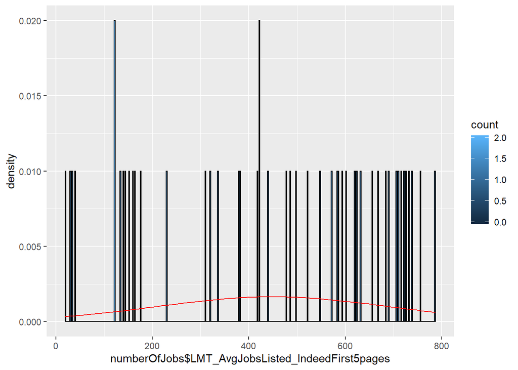

```r
gg <- ggplot(numberOfJobs, aes(x=numberOfJobs$LMT_AvgJobsListed_IndeedFirst5pages))
gg <- gg + geom_histogram(binwidth=2, colour="black",
                          aes(y=..density.., fill=..count..))
gg <- gg + stat_function(fun=dnorm,
                         color="red",
                         args=list(mean=mean(numberOfJobs$LMT_AvgJobsListed_IndeedFirst5pages),
                                  sd=sd(numberOfJobs$LMT_AvgJobsListed_IndeedFirst5pages)))

gg
```

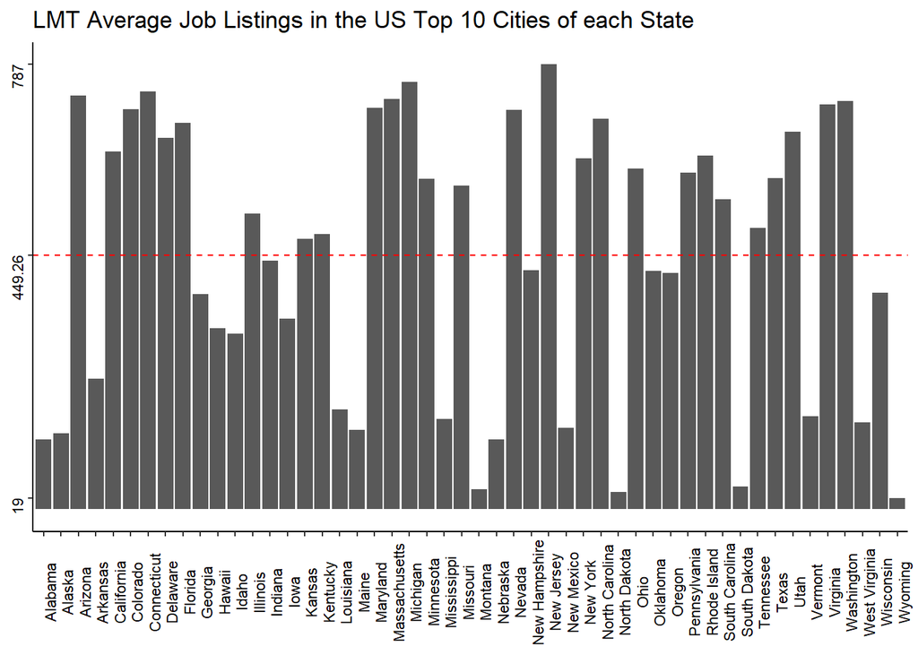

```r
avg <- mean(numberOfJobs$LMT_AvgJobsListed_IndeedFirst5pages)
m <- min(numberOfJobs$LMT_AvgJobsListed_IndeedFirst5pages)
M <- max(numberOfJobs$LMT_AvgJobsListed_IndeedFirst5pages)

ggplot(data = numberOfJobs, aes(y=numberOfJobs$LMT_AvgJobsListed_IndeedFirst5pages, x=numberOfJobs$state)) +
  geom_bar(stat='identity', position=position_dodge())+
  scale_y_continuous(breaks=c(m,avg,M),labels=c(m,avg,M))+
  scale_fill_brewer(palette='Paired') +
  geom_hline(yintercept=mean(numberOfJobs$LMT_AvgJobsListed_IndeedFirst5pages), linetype="dashed", color = "red")+
  theme_classic()+
  theme(legend.position="bottom")+
  theme(axis.text = element_text(colour = "black", angle=90, size = rel(.75)))+
  ggtitle('LMT Average Job Listings in the US Top 10 Cities of each State')+
  ylab(NULL)+
  xlab(NULL)
```

Lets look at those states whose job listings on Indeed are more than the US average job listings for licensed massage therapists.

```r
moreThanAvgLMT <- subset(numberOfJobs, numberOfJobs$LMT_AvgJobsListed_IndeedFirst5pages>avg)
moreThanAvgLMT$state
```

```
##  [1] Arizona        California     Colorado       Connecticut    Delaware
##  [6] Florida        Illinois       Kansas         Kentucky       Maryland
## [11] Massachusetts  Michigan       Minnesota      Missouri       Nevada
## [16] New Jersey     New York       North Carolina Ohio           Pennsylvania
## [21] Rhode Island   South Carolina Tennessee      Texas          Utah
## [26] Virginia       Washington
## 50 Levels: Alabama Alaska Arizona Arkansas California Colorado ... Wyoming
```

Now, lets see which states have fewer than the US average number of job listings for LMT on Indeed.

```r
lessThanAvgLMT <- subset(numberOfJobs, numberOfJobs$LMT_AvgJobsListed_IndeedFirst5pages<avg)
lessThanAvgLMT$state
```

```
##  [1] Alabama       Alaska        Arkansas      Georgia       Hawaii
##  [6] Idaho         Indiana       Iowa          Louisiana     Maine
## [11] Mississippi   Montana       Nebraska      New Hampshire New Mexico
## [16] North Dakota  Oklahoma      Oregon        South Dakota  Vermont
## [21] West Virginia Wisconsin     Wyoming
## 50 Levels: Alabama Alaska Arizona Arkansas California Colorado ... Wyoming
```

From the above, Alaska and many southern and sierra mountain range north mid-western states as well as Hawaii don’t have as many job listings for massage therapists as the more city or urban states do. Surprising Georgia is on this list, as that state has a large somewhat urban population and high pay for LMTs on average compared to other states. Lets look at the pay visually for the 50 states to see this claim just made as true or false.

```r
payRates <- slr[,c(1,33,46,49,52,55,58,61,64,67,70,73,76)]
payRates
```

```
##             state LMT_HourlyAvgPayRangeAdvertised_Indeed cashier_avgHourly
## 1         Alabama                               33.47581         10.779556
## 2          Alaska                               45.27311         13.380329
## 3         Arizona                               37.33333         13.505906
## 4        Arkansas                               21.22124         11.292976
## 5      California                               38.09693         14.956077
## 6        Colorado                               38.09287         14.450483
## 7     Connecticut                               40.17524         12.741473
## 8        Delaware                               32.77984         11.204478
## 9         Florida                               58.40497         11.663638
## 10        Georgia                               45.82667         10.996231
## 11         Hawaii                               31.00000         13.121403
## 12          Idaho                               36.99837         10.984470
## 13       Illinois                               35.72801         12.238977
## 14        Indiana                               37.48912         10.632736
```

[output cut: 189 more lines]

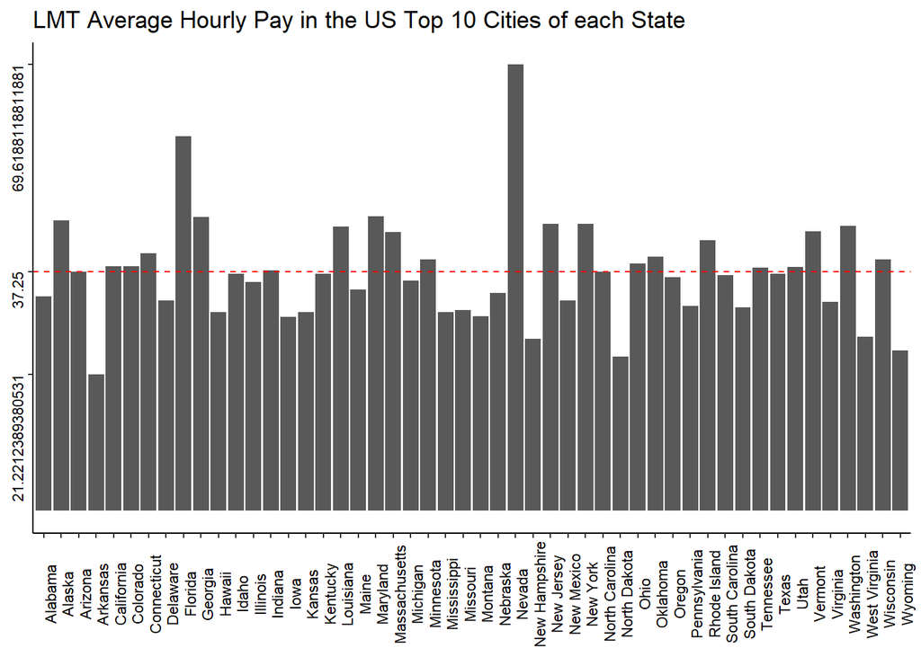

```r
avgPay <- round(mean(payRates$LMT_HourlyAvgPayRangeAdvertised_Indeed,na.rm=TRUE),2)
mPay <- min(payRates$LMT_HourlyAvgPayRangeAdvertised_Indeed,na.rm=TRUE)
MPay <- max(payRates$LMT_HourlyAvgPayRangeAdvertised_Indeed,na.rm=TRUE)

ggplot(data = numberOfJobs, aes(y=payRates$LMT_HourlyAvgPayRangeAdvertised_Indeed, x=payRates$state)) +
  geom_bar(stat='identity', position=position_dodge(), na.rm=TRUE)+
  scale_y_continuous(breaks=c(mPay,avgPay,MPay),labels=c(mPay,avgPay,MPay))+
  scale_fill_brewer(palette='Paired') +
  geom_hline(yintercept=mean(payRates$LMT_HourlyAvgPayRangeAdvertised_Indeed, na.rm=TRUE), linetype="dashed", color = "red")+
  theme_classic()+
  theme(legend.position="bottom")+
  theme(axis.text = element_text(colour = "black", angle=90, size = rel(.75)))+
  ggtitle('LMT Average Hourly Pay in the US Top 10 Cities of each State')+
  ylab(NULL)+
  xlab(NULL)
```

Lets see what states are paying their massage therapists more than the US average. Visually, above we can see Georgia does, and that GA is also in the list of the states with less than the average number of LMT job listings in the US per state. This logically indicates there is a demand for massage therapists in these states, and that the businesses offering massage therapy need LMTs and are willing to offer them more pay.

```r
morePayThanAvgLMT <- subset(payRates, payRates$LMT_HourlyAvgPayRangeAdvertised_Indeed > avgPay)
morePayThanAvgLMT$state
```

```
##  [1] Alaska        Arizona       California    Colorado      Connecticut
##  [6] Florida       Georgia       Indiana       Louisiana     Maryland
## [11] Massachusetts Minnesota     Nevada        New Jersey    New York
## [16] Ohio          Oklahoma      Rhode Island  Tennessee     Utah
## [21] Vermont       Washington    Wisconsin
## 50 Levels: Alabama Alaska Arizona Arkansas California Colorado ... Wyoming
```

Lets see which states offer more than the national LMT average hourly pay and are also in the list of states with less than the national average number of LMT job listings.

```r
fewListings <- lessThanAvgLMT$state
morePayAdvertised <- morePayThanAvgLMT$state

demandStatesLMT <- fewListings %in% morePayAdvertised
demanded <- fewListings[demandStatesLMT]
demanded
```

```
## [1] Alaska    Georgia   Indiana   Louisiana Oklahoma  Vermont   Wisconsin
## 50 Levels: Alabama Alaska Arizona Arkansas California Colorado ... Wyoming
```

Using this same logic, it is fair to say those states that have a higher than average demand for massage therapists and also more pay than average for massage therapists must also be states where the cost of living is higher than normal. Lets look at those states and compare their home values for a two bedroom Zillow listed price from our larger data table called slr.

```r
moreListings <- moreThanAvgLMT$state

highCostStates <- moreListings %in% morePayAdvertised
highLivingCost <- moreListings[highCostStates]
highLivingCost
```

```
##  [1] Arizona       California    Colorado      Connecticut   Florida
##  [6] Maryland      Massachusetts Minnesota     Nevada        New Jersey
## [11] New York      Ohio          Rhode Island  Tennessee     Utah
## [16] Washington
## 50 Levels: Alabama Alaska Arizona Arkansas California Colorado ... Wyoming
```

```r
avgHomePrice <- round(mean(slr$Zillow_2BR_10cityAverageHomeValue,na.rm=T),2)
mHomePrice <- round(min(slr$Zillow_2BR_3cityAverageHomeValue),2)
MHomePrice <- round(max(slr$Zillow_2BR_3cityAverageHomeValue),2)
```

[figure not shown]

```r
ggplot(data = slr$Zillow_2BR_3cityAverageHomeValue,
       aes(y=slr$Zillow_2BR_3cityAverageHomeValue, x=slr$state)) +
  geom_col(aes(y=slr$Zillow_2BR_10cityAverageHomeValue,x=slr$state)) +
  scale_y_continuous(breaks=c(mHomePrice,avgHomePrice,MHomePrice),
                     labels=c(mHomePrice,avgHomePrice,MHomePrice))+
  scale_fill_brewer(palette='Paired') +
  geom_hline(yintercept=avgHomePrice, linetype="dashed", color = "red")+
  theme_classic()+
  theme(legend.position="bottom")+
  theme(axis.text = element_text(colour = "black", angle=90, size = rel(.75)))+
  ggtitle('Zillow 2 Bedroom Home Value in the US Top 10 Cities of each State')+
  ylab(NULL)+
  xlab(NULL)
```

Lets see exactly which states have higher priced homes than the national average.

```r
expensiveHomes <- subset(slr,slr$Zillow_2BR_10cityAverageHomeValue > avgHomePrice)
e <- expensiveHomes$state
e
```

```
##  [1] Alaska        Arizona       California    Colorado      Hawaii
##  [6] Idaho         Maine         Massachusetts Minnesota     Montana
## [11] Nevada        New Jersey    New York      Oregon        Rhode Island
## [16] Utah          Virginia      Washington    Wyoming
## 50 Levels: Alabama Alaska Arizona Arkansas California Colorado ... Wyoming
```

Lets see if those states are also in the list of states with high living costs.

```r
expensive <- expensiveHomes$state %in% highLivingCost
expensiveHomes <- e[expensive]
expensiveHomes
```

```
##  [1] Arizona       California    Colorado      Massachusetts Minnesota
##  [6] Nevada        New Jersey    New York      Rhode Island  Utah
## [11] Washington
## 50 Levels: Alabama Alaska Arizona Arkansas California Colorado ... Wyoming
```

Lets see which states have lower priced homes than the national average but also have higher pay advertised for LMTs and more job listings advertised for LMTs.

```r
inexpensiveHomes <- subset(slr,slr$Zillow_2BR_10cityAverageHomeValue < avgHomePrice)
inexpensive <- inexpensiveHomes$state

notExpensive <- inexpensive %in% highLivingCost
affordable <- inexpensive[notExpensive]
affordable
```

```
## [1] Connecticut Florida     Maryland    Ohio        Tennessee
## 50 Levels: Alabama Alaska Arizona Arkansas California Colorado ... Wyoming
```

We have a couple lists we generated, one for the higher priced states that also pay more for LMTs and have more jobs available called ‘expensiveHomes’, and another list that is the list of states that aren’t as expensive but also pay more for LMTs and have more jobs available for LMTs called ‘affordable’ that we can compare other factors in our large dataset called slr. We also have a third list called ‘demanded’ that lists those states that don’t have as many jobs available as the national average for LMTs but pays more than the national average. Lets see if those states are in our list of states with a higher than national average home according to Zillow’s two bedroom home values that was named ‘e’ for expensive homes by state.

```r
demanded
```

```
## [1] Alaska    Georgia   Indiana   Louisiana Oklahoma  Vermont   Wisconsin
## 50 Levels: Alabama Alaska Arizona Arkansas California Colorado ... Wyoming
```

```r
demanded %in% e
```

```
## [1]  TRUE FALSE FALSE FALSE FALSE FALSE FALSE
```

So, we actually have four lists: **e** is the list of states with expensive homes, **demanded** is our list of states with demand has influenced LMT pay to higher for LMTs than the national average, **expensiveHomes** is our list of states with high cost of living based on higher home values and that also pay more and have more jobs available for LMTs, and our 4th list is the **affordable** list of lower cost of living by home price less than national average but also that has higher pay and more jobs available for LMTs than the national average.

Lets look at the demographics of the states that are in our affordable list and compare to the demographics or our expensiveHomes list to get an idea of the diversity.

```r
demographics <- subset(slr, slr$state %in% affordable)
demographics2 <- demographics[,c(1,37:44)]
demographics2
```

```
##          state total_state_population percent_black percent_white
## 7  Connecticut                3572665          11.0          75.2
## 9      Florida               21299325          16.0          74.6
## 20    Maryland                6042718          30.0          54.7
## 35        Ohio               11689442          12.4          81.0
## 42   Tennessee                6770010          16.8          77.3
##    percent_two_or_more percent_Native_American percent_Asian
## 7                  3.4                     0.3           4.6
## 9                  2.9                     0.3           2.8
## 20                 3.7                     0.2           6.3
## 35                 3.1                     0.2           2.3
## 42                 2.2                     0.3           1.8
##    percent_Pacific_Islander percent_Latino
## 7                       0.0           16.5
## 9                       0.1           26.1
## 20                      0.1           10.4
## 35                      0.0            3.9
## 42                      0.1            5.5
```

Lets look at this above chart of affordable states for LMTs compared to the demographics of CA.

```r
CA_demog <- subset(slr, slr$state=='California')
CA_demog2 <- CA_demog[,c(1,37:44)]
CA_demog2
```

```
##        state total_state_population percent_black percent_white
## 5 California               39557045           5.8          59.5
##   percent_two_or_more percent_Native_American percent_Asian
## 5                 5.1                     0.8          14.7
##   percent_Pacific_Islander percent_Latino
## 5                      0.4           39.3
```

When comparing demographics of percent race to population, it could be similar in fashion to looking for an alternate planet similar to Earth in a vast universe. But we can see the state with a closer distribution of the population by Asian, Latino, Black, and two or more races to compare as elements of a planet in analogy to that similar comparison.

```r
altjobs_aff <- demographics[,c(1,32,45,48,51,54,57,60,63,66,69,72,75)]
CA_altjobs <- CA_demog[,c(1,32,45,48,51,54,57,60,63,66,69,72,75)]
altjobs_aff
```

```
##          state LMT_AvgJobsListed_IndeedFirst5pages cashier_jobsListed
## 7  Connecticut                                 739                689
## 9      Florida                                 684                712
## 20    Maryland                                 710                729
## 35        Ohio                                 603                726
## 42   Tennessee                                 498                709
##    remote_jobsListed personalTrainer_jobsListed houseCleaner_jobsListed
## 7                752                        650                     645
## 9                766                        596                     553
## 20               762                        712                     697
## 35               763                        531                     588
## 42               764                        373                     586
##    warehouse_jobsListed security_jobsListed nanny_jobsListed
## 7                   788                1142              668
## 9                   752                 743              509
## 20                  780                 770              712
## 35                  812                 739              590
## 42                  778                 744               30
##    clerical_jobsListed tutor_jobsListed personal_assistant_jobsListed
## 7                  754              720                           623
## 9                  748              725                           597
## 20                 756              761                           726
## 35                 766              711                           592
## 42                 718              612                           493
##    dataScientist_jobsListed
## 7                       694
## 9                       529
## 20                      806
## 35                      490
## 42                      458
```

```r
CA_altjobs
```

```
##        state LMT_AvgJobsListed_IndeedFirst5pages cashier_jobsListed
## 5 California                                 633                757
##   remote_jobsListed personalTrainer_jobsListed houseCleaner_jobsListed
## 5               751                        590                     622
##   warehouse_jobsListed security_jobsListed nanny_jobsListed clerical_jobsListed
## 5                  790                 783              619                 760
##   tutor_jobsListed personal_assistant_jobsListed dataScientist_jobsListed
## 5              740                           662                      624
```

Now, lets compare CA to our list of expensive states for demographics and alternate jobs available. CA is in our list of expensive states, so we don’t have to do separate table chart comparisons.

```r
expensiveDemog <- subset(slr, slr$state %in% expensiveHomes)
expensiveDemog2 <- expensiveDemog[,c(1,37:44)]
expensiveDemog2
```

```
##            state total_state_population percent_black percent_white
## 3        Arizona                7171646           4.7          78.0
## 5     California               39557045           5.8          59.5
## 6       Colorado                5695564           4.2          84.1
## 21 Massachusetts                6902149           7.8          77.3
## 23     Minnesota                5611179           6.6          82.5
## 28        Nevada                3034392           9.2          63.4
## 30    New Jersey                8908520          13.6          66.9
## 32      New York               19542209          15.7          63.3
## 39  Rhode Island                1057315           6.7          80.7
## 44          Utah                3161105           1.3          85.7
## 47    Washington                7535591           3.9          74.8
##    percent_two_or_more percent_Native_American percent_Asian
## 3                  4.0                     4.6           3.3
## 5                  5.1                     0.8          14.7
```

[output cut: 21 more lines]

Now, we will compare the alternate jobs available in our list of expensive states that includes CA.

```r
altJobs_expStates <- expensiveDemog[,c(1,32,45,48,51,54,57,60,63,66,69,72,75)]
altJobs_expStates
```

```
##            state LMT_AvgJobsListed_IndeedFirst5pages cashier_jobsListed
## 3        Arizona                                 732                762
## 5     California                                 633                757
## 6       Colorado                                 708                725
## 21 Massachusetts                                 726                750
## 23     Minnesota                                 584                753
## 28        Nevada                                 707                748
## 30    New Jersey                                 787                769
## 32      New York                                 621                701
## 39  Rhode Island                                 625                759
## 44          Utah                                 668                759
## 47    Washington                                 722                756
##    remote_jobsListed personalTrainer_jobsListed houseCleaner_jobsListed
## 3                735                        635                     722
## 5                751                        590                     622
```

[output cut: 45 more lines]

Lets now plot the number of available jobs by category in CA compared to New Jersey and New York.

```r
NY_altJobs <- subset(altJobs_expStates, altJobs_expStates$state=='New York')
CA_altJobs <- subset(altJobs_expStates, altJobs_expStates$state=='California')
NJ_altJobs <- subset(altJobs_expStates, altJobs_expStates$state=='New Jersey')

NY_tidyJobs <- gather(NY_altJobs,key="jobTitle", value="jobsListed",2:13, na.rm=TRUE)
NY_tidyJobs$jobTitle <- gsub('_.*$','',NY_tidyJobs$jobTitle, perl=TRUE)

CA_tidyJobs <- gather(CA_altJobs,key="jobTitle", value="jobsListed",2:13, na.rm=TRUE)
CA_tidyJobs$jobTitle <- gsub('_.*$','',CA_tidyJobs$jobTitle, perl=TRUE)

NJ_tidyJobs <- gather(NJ_altJobs,key="jobTitle", value="jobsListed",2:13, na.rm=TRUE)
NJ_tidyJobs$jobTitle <- gsub('_.*$','',NJ_tidyJobs$jobTitle, perl=TRUE)
```

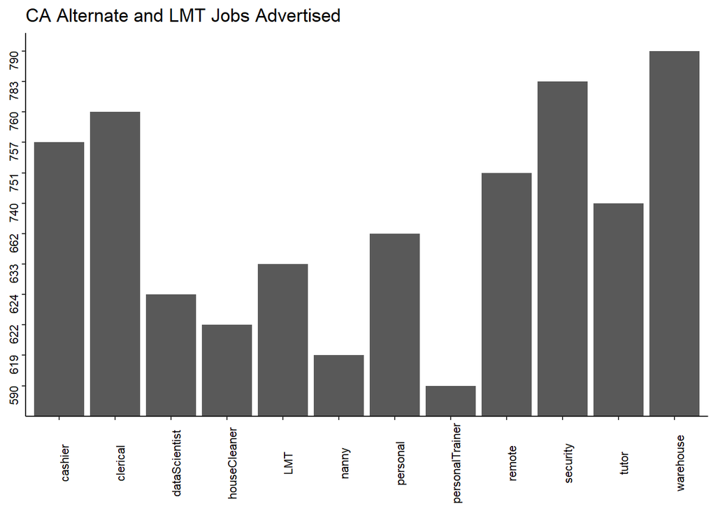

```r
ggplot(data = CA_tidyJobs, aes(y=CA_tidyJobs$jobsListed, x=CA_tidyJobs$jobTitle)) +
  geom_bar(stat='identity', position=position_dodge())+
  scale_fill_brewer(palette='Paired') +
  theme_classic()+
  theme(legend.position="bottom")+
  theme(axis.text = element_text(colour = "black", angle=90, size = rel(.75)))+
  ggtitle('CA Alternate and LMT Jobs Advertised')+
  ylab(NULL)+
  xlab(NULL)
```

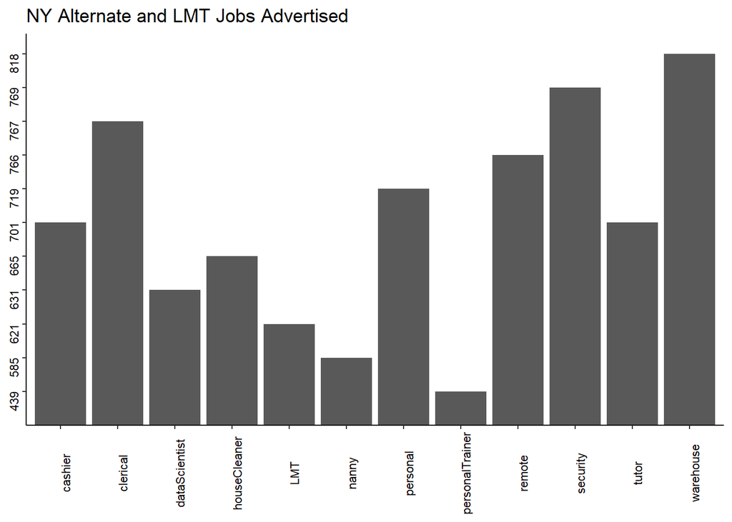

```r
ggplot(data = NY_tidyJobs, aes(y=NY_tidyJobs$jobsListed, x=NY_tidyJobs$jobTitle)) +
  geom_bar(stat='identity', position=position_dodge())+
  scale_fill_brewer(palette='Paired') +
  theme_classic()+
  theme(legend.position="bottom")+
  theme(axis.text = element_text(colour = "black", angle=90, size = rel(.75)))+
  ggtitle('NY Alternate and LMT Jobs Advertised')+
  ylab(NULL)+
  xlab(NULL)
```

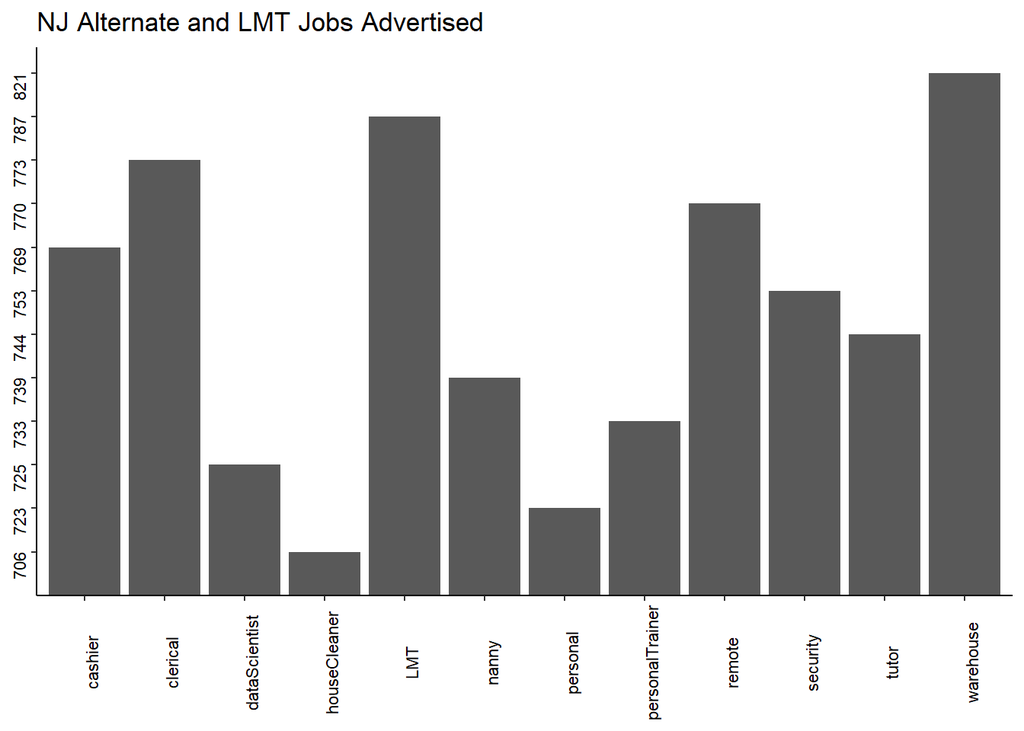

```r
ggplot(data = NJ_tidyJobs, aes(y=NJ_tidyJobs$jobsListed, x=NJ_tidyJobs$jobTitle)) +
  geom_bar(stat='identity', position=position_dodge())+
  scale_fill_brewer(palette='Paired') +
  theme_classic()+
  theme(legend.position="bottom")+
  theme(axis.text = element_text(colour = "black", angle=90, size = rel(.75)))+
  ggtitle('NJ Alternate and LMT Jobs Advertised')+
  ylab(NULL)+
  xlab(NULL)
```

Now, lets compare the pay to each of these states of CA, NY, and AZ. To see how LMTs get paid compared to these alternative jobs in those states.

```r
NY_pay <- subset(slr, slr$state=='New York')
NY_pay2 <- NY_pay[,c(1,34,47,50,53,56,59,62,65,68,71,74,77)]
CA_pay <- subset(slr, slr$state=='California')
CA_pay2 <- CA_pay[,c(1,34,47,50,53,56,59,62,65,68,71,74,77)]
AZ_pay <- subset(slr, slr$state=='Arizona')
AZ_pay2 <- AZ_pay[,c(1,34,47,50,53,56,59,62,65,68,71,74,77)]

NY_PAY <- gather(NY_pay2,key='jobTitle',value='AnnualPay',2:13)
NY_PAY$jobTitle <- gsub('_.*$','',NY_PAY$jobTitle)
CA_PAY <- gather(CA_pay2,key='jobTitle',value='AnnualPay',2:13)
CA_PAY$jobTitle <- gsub('_.*$','',CA_PAY$jobTitle)
AZ_PAY <- gather(AZ_pay2, key='jobTitle',value='AnnualPay',2:13)
AZ_PAY$jobTitle <- gsub('_.*$','',AZ_PAY$jobTitle)
```

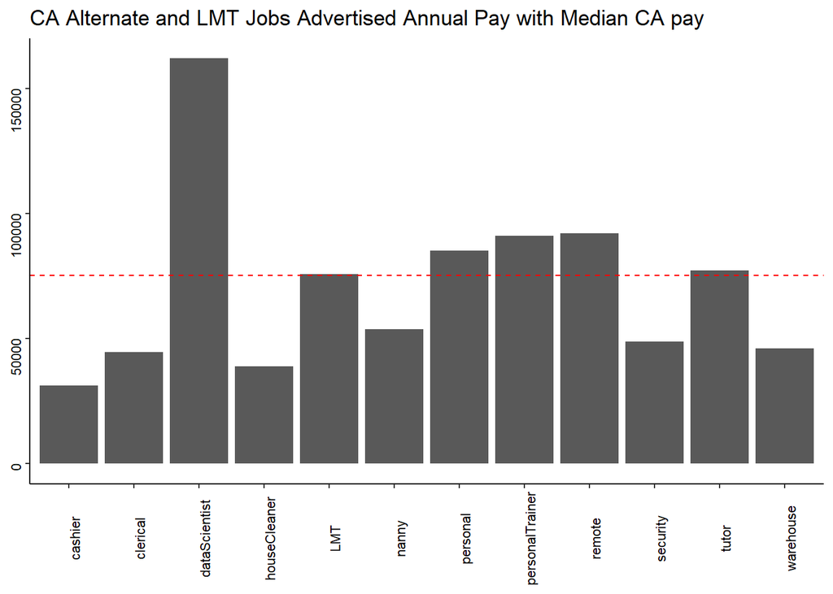

```r
ggplot(data = CA_PAY, aes(y=CA_PAY$AnnualPay, x=CA_PAY$jobTitle)) +
  geom_bar(stat='identity', position=position_dodge())+
  scale_fill_brewer(palette='Paired') +
  geom_hline(yintercept=mean(CA_pay$median2018IncomeByState), linetype="dashed", color = "red")+
  theme_classic()+
  theme(legend.position="bottom")+
  theme(axis.text = element_text(colour = "black", angle=90, size = rel(.75)))+
  ggtitle('CA Alternate and LMT Jobs Advertised Annual Pay with Median CA pay')+
  ylab(NULL)+
  xlab(NULL)
```

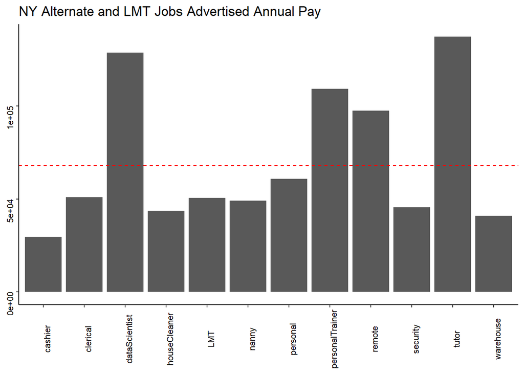

```r
ggplot(data = NY_PAY, aes(y=NY_PAY$AnnualPay, x=NY_PAY$jobTitle)) +
  geom_bar(stat='identity', position=position_dodge())+
  scale_fill_brewer(palette='Paired') +
  geom_hline(yintercept=mean(NY_pay$median2018IncomeByState), linetype="dashed", color = "red")+
  theme_classic()+
  theme(legend.position="bottom")+
  theme(axis.text = element_text(colour = "black", angle=90, size = rel(.75)))+
  ggtitle('NY Alternate and LMT Jobs Advertised Annual Pay')+
  ylab(NULL)+
  xlab(NULL)
```

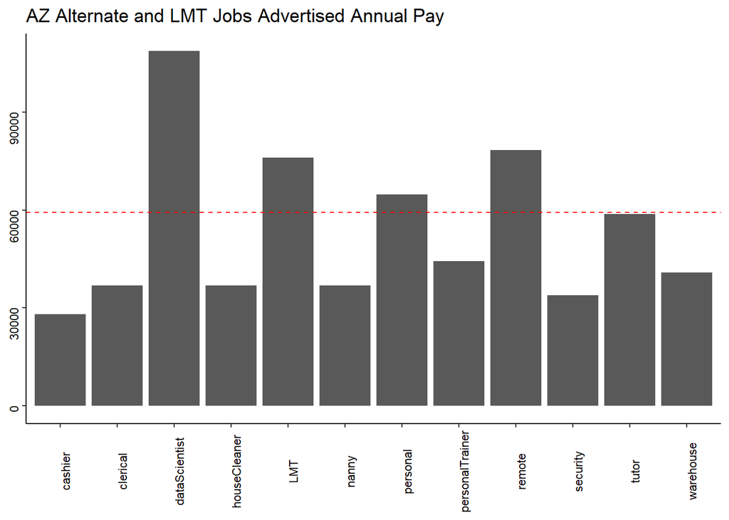

```r
ggplot(data = AZ_PAY, aes(y=AZ_PAY$AnnualPay, x=AZ_PAY$jobTitle)) +
  geom_bar(stat='identity', position=position_dodge())+
  scale_fill_brewer(palette='Paired') +
  geom_hline(yintercept=mean(AZ_pay$median2018IncomeByState), linetype="dashed", color = "red")+
  theme_classic()+
  theme(legend.position="bottom")+
  theme(axis.text = element_text(colour = "black", angle=90, size = rel(.75)))+
  ggtitle('AZ Alternate and LMT Jobs Advertised Annual Pay')+
  ylab(NULL)+
  xlab(NULL)
```

Lets look at some other salaries from other professions, that reflect the state of our economy. I have ran the function to pull the wage information and number of jobs listed for nurses, medical doctors, chiropractors, physical therapists, estheticians, medical spa technicians, and personal assistants. Lets see what our data tells us in a state by state comparison.

```r
nurses <- read.csv('./Indeed 10/jobListings_nurse.csv', sep=',',
                    header=TRUE, na.strings=c('',' ','NA'))
personalAssistants <- read.csv('./Indeed 10/jobListings_personal assistant.csv', sep=',',
                   header=TRUE, na.strings=c('',' ','NA'))
chiropractor <- read.csv('./Indeed 10/jobListings_chiropractor.csv', sep=',',
                   header=TRUE, na.strings=c('',' ','NA'))
physicalTherapist <- read.csv('./Indeed 10/jobListings_physical therapist.csv', sep=',',
                   header=TRUE, na.strings=c('',' ','NA'))
esthetician <- read.csv('./Indeed 10/jobListings_esthetician.csv', sep=',',
                   header=TRUE, na.strings=c('',' ','NA'))
medicalSpaEsthetician <- read.csv('./Indeed 10/jobListings_medical spa technician.csv', sep=',',
                   header=TRUE, na.strings=c('',' ','NA'))
medicalDoctor <- read.csv('./Indeed 10/jobListings_medical doctor.csv', sep=',',
                   header=TRUE, na.strings=c('',' ','NA'))
yogaInstructor <- read.csv('./Indeed 10/jobListings_yoga Instructor.csv', sep=',',
                   header=TRUE, na.strings=c('',' ','NA'))
pilatesInstructor <- read.csv('./Indeed 10/jobListings_pilates Instructor.csv', sep=',',
                   header=TRUE, na.strings=c('',' ','NA'))
```

```r
nurses$stateName <- states
nurses <- nurses[,c(1,10,2:9)]
head(nurses)
```

```
##   state  stateName jobsListed jobSearched MinHourlySalary MaxHourlySalary
## 1    ak     Alaska        775       nurse        25.41065        76.60785
## 2    al    Alabama        816       nurse        16.35723        43.93382
## 3    ar   Arkansas        811       nurse        17.52035        47.84032
## 4    az    Arizona        840       nurse        14.68452       116.12440
## 5    ca California        809       nurse        20.80346        87.48529
## 6    co   Colorado        843       nurse        19.65540        52.32977
##   MinAnnualSalary MaxAnnualSalary avgHourly avgAnualSalary
## 1        47140.38       143535.69  51.00925       95338.04
## 2        39401.13       104762.02  30.14553       72081.57
## 3        55837.13        95360.03  32.68033       75598.58
## 4        50119.35       177709.58  65.40446      113914.47
## 5        42531.50       155558.91  54.14438       99045.20
## 6        42890.84       108871.46  35.99259       75881.15
```

```r
personalAssistants$stateName <- states
personalAssistants <- personalAssistants[,c(1,10,2:9)]
head(personalAssistants)
```

```
##   state  stateName jobsListed        jobSearched MinHourlySalary
## 1    ak     Alaska        225 personal assistant       14.000000
## 2    al    Alabama        408 personal assistant        9.301323
## 3    ar   Arkansas        282 personal assistant        8.882353
## 4    az    Arizona        696 personal assistant       11.211207
## 5    ca California        662 personal assistant       11.768882
## 6    co   Colorado        636 personal assistant       12.000000
##   MaxHourlySalary MinAnnualSalary MaxAnnualSalary avgHourly avgAnualSalary
## 1        26.70455        30000.00        62874.00  20.35227       46437.00
## 2        14.21429        19517.91        29787.88  11.75780       24652.89
## 3        19.11765        34176.62        51577.31  14.00000       42876.97
## 4        25.50718        32909.48        96717.14  18.35920       64813.31
## 5        34.43142        34729.53       135436.88  23.10015       85083.21
## 6        24.95881        31631.51        74969.51  18.47941       53300.51
```

```r
#nd and wy are missing,
ch1 <- chiropractor[1:27,]
ch2 <- chiropractor[28:48,]
ch3 <- chiropractor[1,]
ch3$state <- 'nd'
ch3[,2:9] <- NA
ch4 <- ch3
ch4$state <- 'wy'

chiropractor <- rbind(ch1,ch3,ch2,ch4)

chiropractor$stateName <- states
chiropractor <- chiropractor[,c(1,10,2:9)]
head(chiropractor)
```

```
##   state  stateName jobsListed  jobSearched MinHourlySalary MaxHourlySalary
## 1    ak     Alaska        125 chiropractor        12.00000        18.00000
## 2    al    Alabama        122 chiropractor        13.15789        37.84211
## 3    ar   Arkansas        110 chiropractor        30.00000        30.00000
## 4    az    Arizona        675 chiropractor        12.11194        38.09701
## 5    ca California        566 chiropractor        17.82625        46.69131
## 6    co   Colorado        544 chiropractor        28.10586        31.56522
##   MinAnnualSalary MaxAnnualSalary avgHourly avgAnualSalary
## 1       100000.00        175000.0  15.00000      137500.00
## 2        73635.35        298620.0  25.50000      186127.67
## 3        61909.09        215590.9  30.00000      138750.00
## 4        48214.00        210089.6  25.10448      129151.78
## 5        50391.12        339907.0  32.25878      195149.05
## 6        33133.59        103855.0  29.83554       68494.27
```

```r
physicalTherapist$stateName <- states
physicalTherapist <- physicalTherapist[,c(1,10,2:9)]
head(physicalTherapist)
```

```
##   state  stateName jobsListed        jobSearched MinHourlySalary
## 1    ak     Alaska        308 physical therapist        60.00000
## 2    al    Alabama        692 physical therapist        40.00000
## 3    ar   Arkansas        610 physical therapist        43.41412
## 4    az    Arizona        797 physical therapist        13.01757
## 5    ca California        768 physical therapist        32.03309
## 6    co   Colorado        776 physical therapist        31.11985
##   MaxHourlySalary MinAnnualSalary MaxAnnualSalary avgHourly avgAnualSalary
## 1        65.00000              NA              NA  62.50000             NA
## 2        45.00000        62941.00        102606.0  42.50000       82773.50
## 3        56.27672              NA              NA  49.84542             NA
## 4        69.00149        52038.24        115443.4  41.00953       83740.83
## 5       115.29496        71857.60        119141.0  73.66403       95499.32
## 6        80.43170        55263.80        118317.4  55.77577       86790.59
```

```r
esthetician$stateName <- states
esthetician <- esthetician[,c(1,10,2:9)]
head(esthetician)
```

```
##   state  stateName jobsListed jobSearched MinHourlySalary MaxHourlySalary
## 1    ak     Alaska         80 esthetician        18.00000        24.00000
## 2    al    Alabama        205 esthetician        13.54889        20.74333
## 3    ar   Arkansas        222 esthetician        10.22951        16.98361
## 4    az    Arizona        676 esthetician        11.24260        53.10651
## 5    ca California        573 esthetician        12.08244       108.94444
## 6    co   Colorado        588 esthetician        12.36021        73.99657
##   MinAnnualSalary MaxAnnualSalary avgHourly avgAnualSalary
## 1        30000.00        50000.00  21.00000       40000.00
## 2        28000.00        35000.00  17.14611       31500.00
## 3        30000.00        45000.00  13.60656       37500.00
## 4        16727.42        70000.00  32.17456       43363.71
## 5        25602.41        73132.53  60.51344       49367.47
## 6        29982.85        66998.28  43.17839       48490.57
```

```r
medicalSpaEsthetician$stateName <- states
medicalSpaEsthetician <- medicalSpaEsthetician[,c(1,10,2:9)]
head(medicalSpaEsthetician)
```

```
##   state  stateName jobsListed            jobSearched MinHourlySalary
## 1    ak     Alaska        620 medical spa technician        15.40645
## 2    al    Alabama        468 medical spa technician        10.51467
## 3    ar   Arkansas        303 medical spa technician        12.04943
## 4    az    Arizona        674 medical spa technician        12.52374
## 5    ca California        205 medical spa technician        14.81481
## 6    co   Colorado        660 medical spa technician        13.06515
##   MaxHourlySalary MinAnnualSalary MaxAnnualSalary avgHourly avgAnualSalary
## 1        32.01787        51751.62        142307.7  23.71216       97029.66
## 2        23.50790        49504.82        127903.7  17.01129       88704.25
## 3        19.28897        75000.00        100000.0  15.66920       87500.00
## 4        20.08012              NA              NA  16.30193             NA
## 5        19.96296        49000.00         70000.0  17.38889       59500.00
## 6        22.93027        43424.97        108120.8  17.99771       75772.89
```

```r
medicalDoctor$stateName <- states
medicalDoctor <- medicalDoctor[,c(1,10,2:9)]
head(medicalDoctor)
```

```
##   state  stateName jobsListed    jobSearched MinHourlySalary MaxHourlySalary
## 1    ak     Alaska        609 medical doctor       25.874516       135.94253
## 2    al    Alabama        717 medical doctor        9.110879       122.27992
## 3    ar   Arkansas        681 medical doctor       17.967695       179.43025
## 4    az    Arizona        777 medical doctor       11.402831        38.38353
## 5    ca California        773 medical doctor       13.055627       107.16041
## 6    co   Colorado        777 medical doctor       12.010039        63.83737
##   MinAnnualSalary MaxAnnualSalary avgHourly avgAnualSalary
## 1        69728.22        349783.6  80.90852      209755.92
## 2        81053.32        279454.1  65.69540      180253.69
## 3        51752.56        350337.7  98.69897      201045.15
## 4        28143.11        163169.0  24.89318       95656.04
## 5        58905.25        244418.7  60.10802      151661.98
## 6        44411.05        246396.4  37.92371      145403.72
```

```r
yogaInstructor$stateName <- states
yogaInstructor <- yogaInstructor[,c(1,10,2:9)]
yogaInstructor$avgAnualSalary <- yogaInstructor$avgHourly*40*52
head(yogaInstructor)
```

```
##   state  stateName jobsListed     jobSearched MinHourlySalary MaxHourlySalary
## 1    ak     Alaska         25 yoga instructor              NA              NA
## 2    al    Alabama         25 yoga instructor              NA              NA
## 3    ar   Arkansas         70 yoga instructor        10.00000        15.00000
## 4    az    Arizona        521 yoga instructor        20.08637        64.04031
## 5    ca California        526 yoga instructor        14.97505        46.50096
## 6    co   Colorado        517 yoga instructor        12.88090       107.52567
##   MinAnnualSalary MaxAnnualSalary avgHourly avgAnualSalary
## 1              NA              NA        NA             NA
## 2              NA              NA        NA             NA
## 3              NA              NA  12.50000       26000.00
## 4              NA              NA  42.06334       87491.75
## 5        59616.59        74215.25  30.73800       63935.05
## 6        32000.00        38000.00  60.20329      125222.83
```

```r
#ak, nd, wy missing
ak <- pilatesInstructor[1,]
ak$state <- 'ak'
ak[,2:9] <- NA
nd <- ak
nd$state <- 'nd'
wy <- ak
wy$state <- 'wy'
p1 <- pilatesInstructor[1:26,]
p2 <- pilatesInstructor[27:47,]

pilatesInstructor <- rbind(ak,p1,nd,p2,wy)

pilatesInstructor$stateName <- states[1:50]
pilatesInstructor <- pilatesInstructor[,c(1,10,2:9)]
head(pilatesInstructor)
```

```
##   state  stateName jobsListed        jobSearched MinHourlySalary
## 1    ak     Alaska         NA               <NA>              NA
## 2    al    Alabama         70 pilates instructor              NA
## 3    ar   Arkansas         15 pilates instructor              NA
## 4    az    Arizona        545 pilates instructor        13.18349
## 5    ca California        536 pilates instructor        15.07186
## 6    co   Colorado        428 pilates instructor        19.45000
##   MaxHourlySalary MinAnnualSalary MaxAnnualSalary avgHourly avgAnualSalary
## 1              NA              NA              NA        NA             NA
## 2              NA              NA              NA        NA             NA
## 3              NA              NA              NA        NA             NA
## 4        14.27523              NA              NA  13.72936             NA
## 5        56.74451        38479.56        87479.56  35.90818       62979.56
## 6       112.06107              NA              NA  65.75553             NA
```

Lets combine these jobs to the slr dataset.

```r
nurses2 <- nurses[,c(2,3,9,10)]
personalAssistants2 <- personalAssistants[,c(2,3,9,10)]
chiropractor2 <- chiropractor[,c(2,3,9,10)]
physicalTherapist2 <- physicalTherapist[,c(2,3,9,10)]
esthetician2 <- esthetician[,c(2,3,9,10)]
medicalSpaEsthetician2 <- medicalSpaEsthetician[,c(2,3,9,10)]
medicalDoctor2 <- medicalDoctor[,c(2,3,9,10)]
yogaInstructor2 <- yogaInstructor[,c(2,3,9,10)]
pilatesInstructor2 <- pilatesInstructor[,c(2,3,9,10)]
```

```r
nurses2$avgAnualSalary <- ifelse(nurses2$avgAnualSalary,nurses2$avgAnualSalary,
                                 nurses2$avgHourly*40*52)
colnames(nurses2)[2:4] <- paste('nurses',colnames(nurses2)[2:4])

personalAssistants2$avgAnualSalary <- ifelse(personalAssistants2$avgAnualSalary,
                                             personalAssistants2$avgAnualSalary,
                                             personalAssistants2$avgHourly*40*52)
colnames(personalAssistants2)[2:4] <- paste('personalAssistant',colnames(personalAssistants2)[2:4])

chiropractor2$avgAnualSalary <- chiropractor2$avgHourly*40*52
colnames(chiropractor2)[2:4] <- paste('chiropractor',colnames(chiropractor2)[2:4])

physicalTherapist2$avgAnualSalary <- physicalTherapist2$avgHourly*40*52
colnames(physicalTherapist2)[2:4] <- paste('physicalTherapist',colnames(physicalTherapist2)[2:4])

esthetician2$avgAnualSalary <- esthetician2$avgHourly*40*52
colnames(esthetician2)[2:4] <- paste('esthetician',colnames(esthetician2)[2:4])

medicalSpaEsthetician2$avgAnualSalary <- medicalSpaEsthetician2$avgHourly*40*52
colnames(medicalSpaEsthetician2)[2:4] <- paste('medicalSpaEsthetician',colnames(medicalSpaEsthetician2)[2:4])

medicalDoctor2$avgAnualSalary <- ifelse(medicalDoctor2$avgAnualSalary,
                                        medicalDoctor2$avgAnualSalary,
                                        medicalDoctor2$avgHourly*40*52)
colnames(medicalDoctor2)[2:4] <- paste('medicalDoctor',colnames(medicalDoctor2)[2:4])
colnames(yogaInstructor2)[2:4] <- paste('yogaInstructor',colnames(yogaInstructor2)[2:4])
pilatesInstructor2$avgAnualSalary <- pilatesInstructor2$avgHourly*40*52
colnames(pilatesInstructor2)[2:4] <- paste('pilatesInstructor',colnames(pilatesInstructor2)[2:4])
```

Combine these other jobs into a table with the slr data table.

```r
slr2 <- merge(slr, nurses2, by.x='state',by.y='stateName')
slr2 <- merge(slr2,personalAssistants2, by.x='state',by.y='stateName')
slr2 <- merge(slr2, chiropractor2, by.x='state',by.y='stateName')
slr2 <- merge(slr2, physicalTherapist2, by.x='state', by.y='stateName')
slr2 <- merge(slr2, esthetician2, by.x='state', by.y='stateName')
slr2 <- merge(slr2, medicalSpaEsthetician2, by.x='state', by.y='stateName')
slr2 <- merge(slr2, medicalDoctor2, by.x='state',by.y='stateName')
slr2 <- merge(slr2, yogaInstructor2, by.x='state',by.y='stateName')
slr2 <- merge(slr2, pilatesInstructor2, by.x='state', by.y='stateName',all.x=TRUE)
```

```r
write.csv(slr2,'stateLicensingDemographicsAddedAndUpdated.csv', row.names=FALSE)
```

Number of jobs listed and average annual salary in each category by state’s top three populated cities:

```r
jbl <- grep('jobsListed',colnames(slr2))
listedJobsAll <- slr2[,c(1,32,jbl)]

ansy <- grep('avgAn',colnames(slr2))
avgSalaryAll <- slr2[,c(1,34,ansy)]
```

```r
colnames(listedJobsAll) <- gsub('_.*$','',colnames(listedJobsAll),perl=TRUE)
colnames(listedJobsAll) <- gsub(' jobsListed','',colnames(listedJobsAll))
listedJobsAll
```

```
##             state LMT cashier remote personalTrainer houseCleaner warehouse
## 1         Alabama 123     664    751             290          290       755
## 2          Alaska 134     375    750             100           45       650
## 3         Arizona 732     762    735             635          722       786
## 4        Arkansas 231     644    754             215          195       738
## 5      California 633     757    751             590          622       790
## 6        Colorado 708     725    743             604          617       854
## 7     Connecticut 739     689    752             650          645       788
## 8        Delaware 657     670    760             494          713       802
## 9         Florida 684     712    766             596          553       752
## 10        Georgia 380     597    747             411          536       720
## 11         Hawaii 320     556    750             165          153       762
## 12          Idaho 311     660    755             195          394       748
## 13       Illinois 523     728    744             485          459       789
## 14        Indiana 440     711    762             410          379       797
```

[output cut: 189 more lines]

```r
colnames(avgSalaryAll) <- gsub('_.*$','',colnames(avgSalaryAll))
colnames(avgSalaryAll) <- gsub(' .*$','',colnames(avgSalaryAll))
avgSalaryAll
```

```
##             state      LMT  cashier    remote personalTrainer houseCleaner
## 1         Alabama 44814.49 22421.48  88527.40        54465.19     26236.36
## 2          Alaska 97500.00 27831.08  95349.97              NA     24960.00
## 3         Arizona 75990.27 28092.28  78325.44        44423.56     36892.63
## 4        Arkansas 42278.00 23489.39  77984.83        54080.00     28304.86
## 5      California 75806.28 31108.64  92184.71        91111.05     38917.40
## 6        Colorado 65703.53 30057.00  88087.86        64184.84     47623.98
## 7     Connecticut 50955.95 26502.26  92360.85        62904.00     35695.78
## 8        Delaware 50000.00 23305.31 102656.21        49531.65     28520.50
## 9         Florida 53584.21 24260.37  97506.11        70555.66     31999.28
## 10        Georgia 49541.67 22872.16  88471.00        63639.90     36170.85
## 11         Hawaii 81461.50 27292.52 108792.32              NA     29120.00
## 12          Idaho 30000.00 22847.70  98477.67        39173.33     28940.64
## 13       Illinois 54477.69 25457.07  83060.22        78342.44     36288.66
## 14        Indiana 71813.96 22116.09  96689.97        59466.11     30715.23
```

[output cut: 189 more lines]

```r
wellnessJobs <- listedJobsAll[,c(1,2,5,16,17,21,22)]
wellnessSalary <- avgSalaryAll[,c(1,2,5,16,17,21,22)]
wellnessJobs
```

```
##             state LMT personalTrainer chiropractor physicalTherapist
## 1         Alabama 123             290          122               692
## 2          Alaska 134             100          125               308
## 3         Arizona 732             635          675               797
## 4        Arkansas 231             215          110               610
## 5      California 633             590          566               768
## 6        Colorado 708             604          544               776
## 7     Connecticut 739             650          263               776
## 8        Delaware 657             494          319               718
## 9         Florida 684             596          589               713
## 10        Georgia 380             411          357               632
## 11         Hawaii 320             165          584               633
## 12          Idaho 311             195          145               535
## 13       Illinois 523             485          431               669
## 14        Indiana 440             410          306               643
```

[output cut: 87 more lines]

Now look at the LMT with esthetician and medical spa esthetician jobs available.Nurses are needed in medical spas that are also estheticians, so we will add that class of jobs listed to our spaJobs data table.

```r
spaJobs <- listedJobsAll[,c(1,2,14,18,19)]
spaSalary <- avgSalaryAll[,c(1,2,14,18,19)]
spaJobs
```

```
##             state LMT nurses esthetician medicalSpaEsthetician
## 1         Alabama 123    816         205                   468
## 2          Alaska 134    775          80                   620
## 3         Arizona 732    840         676                   674
## 4        Arkansas 231    811         222                   303
## 5      California 633    809         573                   205
## 6        Colorado 708    843         588                   660
## 7     Connecticut 739    815         661                    70
## 8        Delaware 657    801         438                   165
## 9         Florida 684    819         593                   360
## 10        Georgia 380    727         346                   508
## 11         Hawaii 320    806         280                   761
## 12          Idaho 311    797         195                   318
## 13       Illinois 523    817         497                   555
## 14        Indiana 440    835         428                   416
```

[output cut: 36 more lines]

Lets used our list of demanded LMT states where there weren’t as many jobs available for LMT, but the pay was higher for LMT than the national LMT average pay.

```r
demanded
```

```
## [1] Alaska    Georgia   Indiana   Louisiana Oklahoma  Vermont   Wisconsin
## 50 Levels: Alabama Alaska Arizona Arkansas California Colorado ... Wyoming
```

```r
GA <- subset(slr2, slr2=='Georgia')
GA_2BR <- GA$Zillow_2BR_3cityAverageHomeValue
GA_medIncome <- GA$median2018IncomeByState

GA_wellness <- subset(wellnessJobs, wellnessJobs$state=='Georgia')
GA_wellnessSalary <- subset(wellnessSalary,wellnessSalary$state=='Georgia')

GA_wellness2 <- gather(GA_wellness, key='jobTitle',value='jobsListed',2:7)
GA_wellnessSalary2 <- gather(GA_wellnessSalary, key='jobTitle', value='annualSalary',2:7)
```

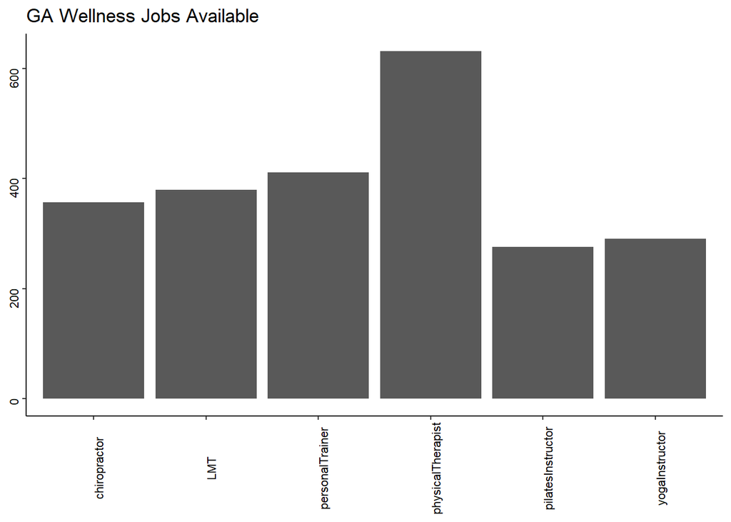

```r
ggplot(data = GA_wellness2, aes(y=GA_wellness2$jobsListed, x=GA_wellness2$jobTitle)) +
  geom_bar(stat='identity', position=position_dodge())+
  scale_fill_brewer(palette='Paired') +
  theme_classic()+
  theme(legend.position="bottom")+
  theme(axis.text = element_text(colour = "black", angle=90, size = rel(.75)))+
  ggtitle('GA Wellness Jobs Available')+
  ylab(NULL)+
  xlab(NULL)
```

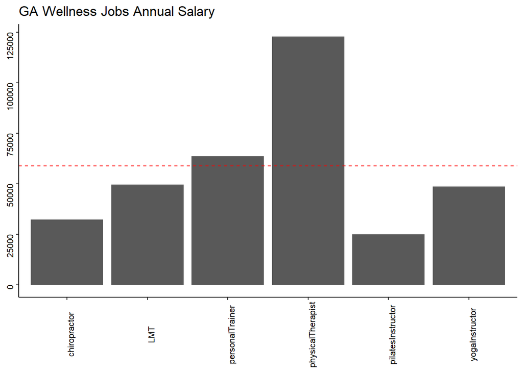

```r
ggplot(data = GA_wellnessSalary2, aes(y=GA_wellnessSalary2$annualSalary, x=GA_wellnessSalary2$jobTitle)) +
  geom_bar(stat='identity', position=position_dodge(),na.rm=TRUE)+
  scale_fill_brewer(palette='Paired') +
  theme_classic()+
  geom_hline(yintercept=GA_medIncome, linetype="dashed", color = "red")+
  geom_hline(yintercept=GA_2BR, linetype='dashed',color='blue')+
  theme(legend.position="bottom")+
  theme(axis.text = element_text(colour = "black", angle=90, size = rel(.75)))+
  ggtitle('GA Wellness Jobs Annual Salary')+
  ylab(NULL)+
  xlab(NULL)
```

Now, lets look at the chart of the medical spas jobs available and annual salary in GA with the same home value and median income values for GA used in the wellness jobs above.

```r
GA_spa <- subset(spaJobs, spaJobs$state=='Georgia')
GA_spaSalary <- subset(spaSalary,spaSalary$state=='Georgia')

GA_spa2 <- gather(GA_spa, key='jobTitle',value='jobsListed',2:5)
GA_spaSalary2 <- gather(GA_spaSalary, key='jobTitle', value='annualSalary',2:5)
```

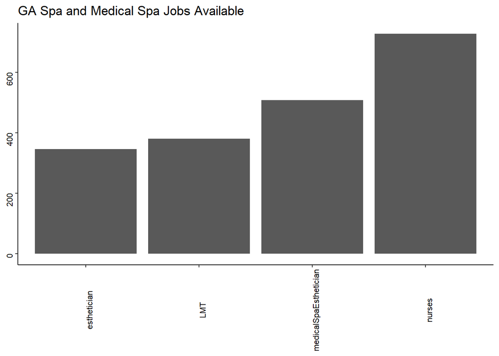

```r
ggplot(data = GA_spa2, aes(y=GA_spa2$jobsListed, x=GA_spa2$jobTitle)) +
  geom_bar(stat='identity', position=position_dodge())+
  scale_fill_brewer(palette='Paired') +
  theme_classic()+
  theme(legend.position="bottom")+
  theme(axis.text = element_text(colour = "black", angle=90, size = rel(.75)))+
  ggtitle('GA Spa and Medical Spa Jobs Available')+
  ylab(NULL)+
  xlab(NULL)
```

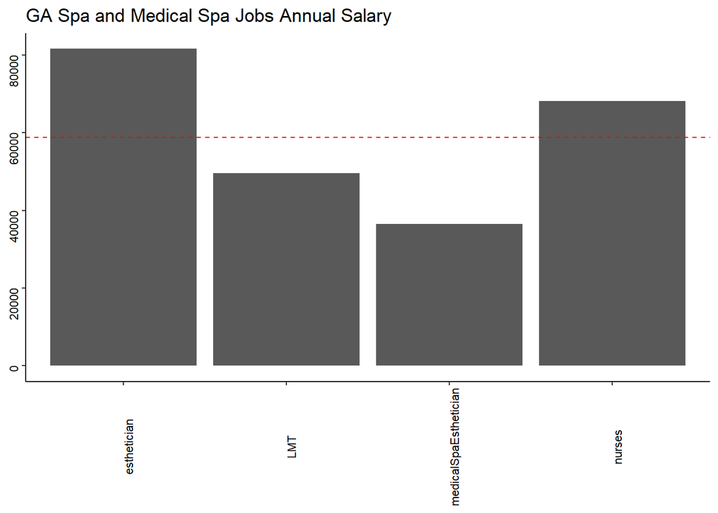

```r
ggplot(data = GA_spaSalary2, aes(y=GA_spaSalary2$annualSalary,
                                 x=GA_spaSalary2$jobTitle)) +
  geom_bar(stat='identity', position=position_dodge())+
  scale_fill_brewer(palette='Paired') +
  theme_classic()+
  geom_hline(yintercept=GA_medIncome, linetype="dashed", color = "red")+
  geom_hline(yintercept=GA_2BR, linetype='dashed',color='blue')+
  theme(legend.position="bottom")+
  theme(axis.text = element_text(colour = "black", angle=90, size = rel(.75)))+
  ggtitle('GA Spa and Medical Spa Jobs Annual Salary')+
  ylab(NULL)+
  xlab(NULL)
```

There is now a script that did similar to what the indeed function did but for yellowpages.com. This script takes the first five webpages of yellowpages.com for the business searched in the city and state and returns a table of the number of businesses of that type in the same three top populated cities per state used in this program. The script is called ‘yellowPages-number-of-businesses.Rmd’ and it was used to get the number of businesses in those three cities per state for coffee, massage, gym, tanning, hair salon, tanning, yoga, chiropractic, wellness, and health food businesses. Lets add these counts to our table slr2 of all features used so far.

```r
ypChiro <- read.csv('./Yellow Pages Businesses/statesRates- chiropractor .csv',
                    sep=',', header=TRUE, na.strings=c('',' ','NA'))
ypWellness <- read.csv('./Yellow Pages Businesses/statesRates- wellness clinic .csv',
                    sep=',', header=TRUE, na.strings=c('',' ','NA'))
ypMassage <- read.csv('./Yellow Pages Businesses/statesRates- massage spa .csv',
                    sep=',', header=TRUE, na.strings=c('',' ','NA'))
ypYoga <- read.csv('./Yellow Pages Businesses/statesRates- yoga .csv',
                    sep=',', header=TRUE, na.strings=c('',' ','NA'))
ypGym <- read.csv('./Yellow Pages Businesses/statesRates- gym .csv',
                    sep=',', header=TRUE, na.strings=c('',' ','NA'))
ypCoffee <- read.csv('./Yellow Pages Businesses/statesRates- coffee .csv',
                    sep=',', header=TRUE, na.strings=c('',' ','NA'))
ypHealthFood <- read.csv('./Yellow Pages Businesses/statesRates- health food .csv',
                    sep=',', header=TRUE, na.strings=c('',' ','NA'))
ypHairSalon <- read.csv('./Yellow Pages Businesses/statesRates- hair salon .csv',
                    sep=',', header=TRUE, na.strings=c('',' ','NA'))
ypTanning <- read.csv('./Yellow Pages Businesses/statesRates- tanning .csv',
                    sep=',', header=TRUE, na.strings=c('',' ','NA'))
```

```r
ypChiro$states <- states
ypWellness$states <- states
ypMassage$states <- states
ypYoga$states <- states
ypGym$states <- states
ypCoffee$states <- states
ypHealthFood$states <- states
ypHairSalon$states <- states
ypTanning$states <- states
```

```r
ypChiro <- ypChiro[,-1]
ypWellness <- ypWellness[,-1]
ypMassage <- ypMassage[,-1]
ypYoga <- ypYoga[,-1]
ypGym <- ypGym[,-1]
ypCoffee <- ypCoffee[,-1]
ypHealthFood <- ypHealthFood[,-1]
ypHairSalon <- ypHairSalon[,-1]
ypTanning <- ypTanning[,-1]
```

```r
slr3 <- merge(slr2,ypChiro, by.x='state', by.y='states')
slr3 <- merge(slr3,ypWellness,by.x='state', by.y='states')
slr3 <- merge(slr3,ypMassage,by.x='state', by.y='states')
slr3 <- merge(slr3,ypYoga,by.x='state', by.y='states')
slr3 <- merge(slr3,ypGym,by.x='state', by.y='states')
slr3 <- merge(slr3,ypCoffee,by.x='state', by.y='states')
slr3 <- merge(slr3,ypHealthFood,by.x='state', by.y='states')
slr3 <- merge(slr3,ypHairSalon,by.x='state', by.y='states')
slr3 <- merge(slr3,ypTanning,by.x='state', by.y='states')
```

```r
colnames(slr3)
```

```
##   [1] "state"
##   [2] "massageBoard"
##   [3] "licenseByReciprocity"
##   [4] "proofOtherOrAllStateLicense"
##   [5] "stateResidencyProof"
##   [6] "passportSizePhoto"
##   [7] "driversLicensePhotoCopy"
##   [8] "nameChangeProof"
##   [9] "socialSecurityCopy"
##  [10] "Hours"
##  [11] "MBLEX_or_NCBTMB"
##  [12] "goodHealthClearance"
##  [13] "BoardBackgroundCheckFee"
##  [14] "stateApplyingBackgroundCheck"
##  [15] "DOJ_backgroundCheck"
```

[output cut: 98 more lines]

```r
write.csv(slr3, 'stateLicensingDemographicsAddedAndUpdated.csv', row.names=FALSE)
```

We currently have the price of 2 bedroom homes using Zillow data, but now we can add in apartments.com data for rental apartments of 2-3 bedroom, 2 bathroom, dog/cat friendly pricing to our data set to compare rental prices in the three top populated cities in each state. It didn’t happen by magic either, there is a script for it very similar to the indeed and yellowpages web scraping scripts. Originally, I was going to use rent.com, but wouldn’t you know they have a web scraping blocker in place that makes sure their terms of use aren’t violated for ‘not downloading their data.’ I did download apartments.com data, but only to share the aggregate results. Each individual file is downloaded for the date pulled but not added to githu. The script is ‘aps-com-2BR-2BA.Rmd’ in github with all these other shared files.I was booted from apartments.com due to so many downloads, but used a VPN that allowed me to take the average of the average, minimum, and maximum prices of up to ten cities that are the most populated cities (rather than the top 3 cities) with prices on aparmtnents.com. It will produce this table in csv format, ‘apts_2BR2BA_prices.csv’ to add to our updated and added state licensing requirements csv table of data to compare state by state. This last file was modified to read in the listings if available of the top 10 most populated cities, as was the Zillow home value listings for 10 most populated cities, instead of for the 3 most populated as the original scripts were done.

```r
apt2and2 <- read.csv('./Apartments 2BR/apts_2BR2BA_prices.csv',sep=',',
                     header=TRUE, na.strings=c('',' ','NA'))
```

```r
head(apt2and2,10)
```

```
##    state TwoBedroomApartment_Listings Rent2BR2BA_MinPrice Rent2BR2BA_MaxPrice
## 1     AK                           65           1503.8136            1633.875
## 2     AL                          428           1033.4785            1429.053
## 3     AR                          253            936.7705            1338.388
## 4     AZ                          784           1316.1770            1977.112
## 5     CA                          753           2800.0942            4221.743
## 6     CO                          575           1721.9841            2736.899
## 7     CT                          168           2133.2250            3099.876
## 8     DE                          334           1866.1101            2874.259
## 9     FL                          788           1577.3072            2200.040
## 10    GA                          603           1553.5892            2586.099
##    Rent2BR2BA_AvgPrice
## 1             1533.517
## 2             1171.429
## 3             1071.283
## 4             1595.761
## 5             3384.555
## 6             2183.487
## 7             2452.688
## 8             2313.078
## 9             1824.755
## 10            2017.370
```

Now lets add these new data columns to our table of 50 states.

```r
colnames(apt2and2)[1] <- 'stateAbbreviation'
colnames(apt2and2)[2:5] <- paste(colnames(apt2and2)[2:5],'_10cities')
apt2and2$stateName <- states
```

```r
slr4 <- merge(slr3,apt2and2, by.x='state',by.y='stateName')
```

```r
colnames(slr4)
```

```
##   [1] "state"
##   [2] "massageBoard"
##   [3] "licenseByReciprocity"
##   [4] "proofOtherOrAllStateLicense"
##   [5] "stateResidencyProof"
##   [6] "passportSizePhoto"
##   [7] "driversLicensePhotoCopy"
##   [8] "nameChangeProof"
##   [9] "socialSecurityCopy"
##  [10] "Hours"
##  [11] "MBLEX_or_NCBTMB"
##  [12] "goodHealthClearance"
##  [13] "BoardBackgroundCheckFee"
##  [14] "stateApplyingBackgroundCheck"
##  [15] "DOJ_backgroundCheck"
```

[output cut: 103 more lines]

```r
slr5 <- slr4[,c(114,1:113,115:118)]
```

```r
write.csv(slr5,'stateLicensingDemographicsAddedAndUpdated.csv',row.names=FALSE)
```

Remember to update the stateLicensingRequirements.csv file with the actual massage board licensing requirements of each state, then adding the additional updated and added features with this script, after using those helper script files to update information as needed.

Getting back to the motivation for this project, comparing TN to CA, to satisfy some gamey choices in moving from CA to TN as a massage therapist to make my youngest and greatly adored neice’s life easier and happier, Lets compare TN to CA in demographics, number of data science and massage therapist jobs, annual salary on average for those jobs, and for alternate jobs, how many health food stores, salons, spas, chiropractors, and coffee shops in each state’s top three most populated cities, what the average and average minimum price range for a two bedroom, two bathroom and pet friendly apartment is, the median income from 2018 data for each state, and see how compromisable the effects of moving from CA to TN would be.

Lets first get all the fields used for this comparison.

```r
comparing_TN_CA <- slr5[,c(1,11,12,17,18,19,23,33,35,37:45,55,57,58,60,
                           64,66,67,69,70,72,76,78,82,84,108:118)]
colnames(comparing_TN_CA)
```

```
##  [1] "stateAbbreviation"
##  [2] "Hours"
##  [3] "MBLEX_or_NCBTMB"
##  [4] "applicationCost"
##  [5] "licensingCost"
##  [6] "licenseRenewalFee"
##  [7] "CEU"
##  [8] "LMT_AvgJobsListed_IndeedFirst5pages"
##  [9] "LMT_AnualAvgPayAdvertised_Indeed"
## [10] "median2018IncomeByState"
## [11] "total_state_population"
## [12] "percent_black"
## [13] "percent_white"
## [14] "percent_two_or_more"
## [15] "percent_Native_American"
```

[output cut: 28 more lines]

Lets compare demographics of each state by the states’ three most populated cities. This is important as it skews necessary information if the cities most populated aren’t near the place planning to live. For CA, the cities were San Diego, Los Angeles, and San Jose. The distance between San Diego and Los Angeles is about 120 miles, and from San Jose to Los Angeles it is more than 400 miles. San Jose is also a popularly expensive high rent city due to silicon valley. For TN, the cities most populated are Nashville, Memphis, and knoxville. The idea is that the pricing will be similar as an average across the state’s three most populated cities.

```r
CA <- subset(comparing_TN_CA, comparing_TN_CA$stateAbbreviation=='CA')
TN <- subset(comparing_TN_CA, comparing_TN_CA$stateAbbreviation=='TN')
```

Lets look at demographics from 2018 state only data using data.census.gov.

```r
CA_demographics <- CA[,c(1,11:18)]
TN_demographics <- TN[,c(1,11:18)]
```

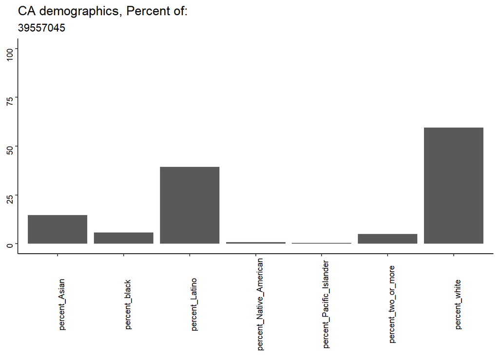

```r
CA_demoTidy <- gather(CA_demographics, key='race', value='TotalPopulationPercent',
                      3:9)
CA_demoTidy$TotalPopulationPercent <- as.numeric(CA_demoTidy$TotalPopulationPercent)
CA_pop <- CA_demographics$total_state_population

gg1 <- ggplot(data = CA_demoTidy,
              aes(y=CA_demoTidy$TotalPopulationPercent,
                  x=CA_demoTidy$race)) +
  geom_bar(stat='identity', position=position_dodge())+
  theme_classic()+
  coord_cartesian(ylim = c(0, 100))+
  theme(legend.position="bottom")+
  theme(axis.text = element_text(colour = "black", angle=90, size = rel(.75)))+
  ggtitle('CA demographics, Percent of: ',CA_pop)+
  ylab(NULL)+
  xlab(NULL)

gg1
```

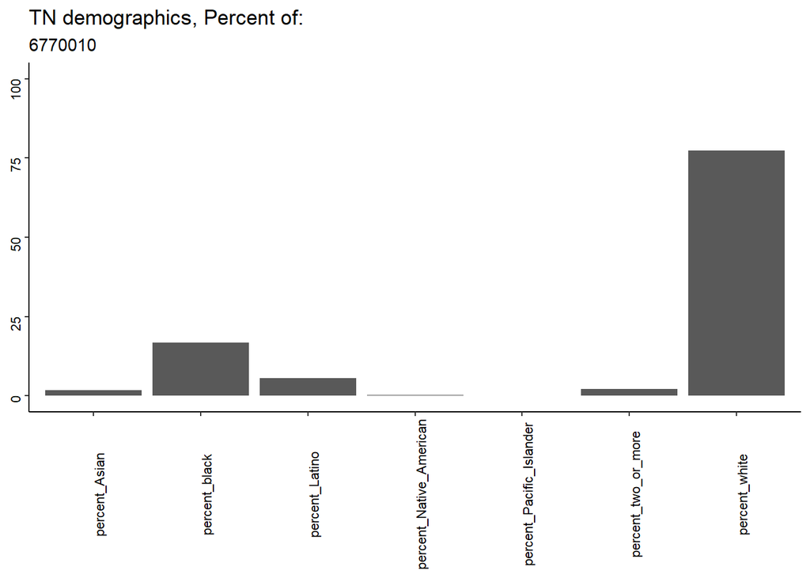

```r
TN_demoTidy <- gather(TN_demographics, key='race', value='TotalPopulationPercent',
                      3:9)
TN_demoTidy$TotalPopulationPercent <- as.numeric(TN_demoTidy$TotalPopulationPercent)
TN_pop <- TN_demographics$total_state_population

gg2 <- ggplot(data = TN_demoTidy,
              aes(y=TN_demoTidy$TotalPopulationPercent,
                  x=TN_demoTidy$race)) +
  geom_bar(stat='identity', position=position_dodge())+
  theme_classic()+
  coord_cartesian(ylim = c(0, 100))+
  theme(legend.position="bottom")+
  theme(axis.text = element_text(colour = "black", angle=90, size = rel(.75)))+
  ggtitle('TN demographics, Percent of: ',TN_pop)+
  ylab(NULL)+
  xlab(NULL)

gg2
```

```r
CA_TN_demographics <- rbind(CA_demographics,TN_demographics)
CA_TN_demographics
```

```
##    stateAbbreviation total_state_population percent_black percent_white
## 5                 CA               39557045           5.8          59.5
## 42                TN                6770010          16.8          77.3
##    percent_two_or_more percent_Native_American percent_Asian
## 5                  5.1                     0.8          14.7
## 42                 2.2                     0.3           1.8
##    percent_Pacific_Islander percent_Latino
## 5                       0.4           39.3
## 42                      0.1            5.5
```

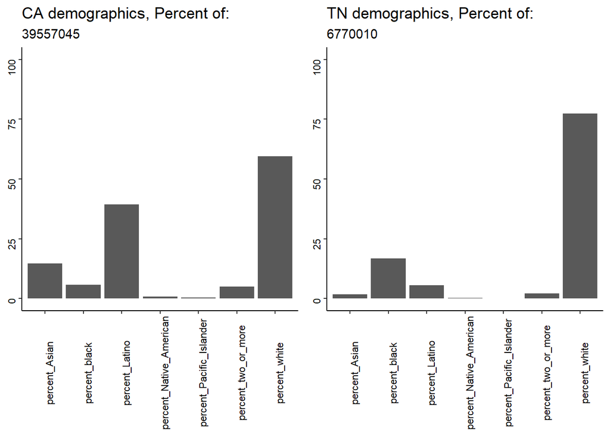

```r
grid.arrange(gg1, gg2, ncol = 2)
```

Now lets look at the two bedroom, two bath, pet friendly apartments for rent in CA and TN.

```r
CA_2BR <- CA[,c(1,40:43)]
TN_2BR <- TN[,c(1,40:43)]
```

```r
CA_listings <- CA_2BR$TwoBedroomApartment_Listings

CA_2BR_tidy <- gather(CA_2BR, key='range',value='price',3:5)
CA_2BR_tidy$range <- gsub('Rent2BR2BA_','',CA_2BR_tidy$range)
gg3 <- ggplot(data = CA_2BR_tidy,
              aes(y=CA_2BR_tidy$price,
                  x=CA_2BR_tidy$range)) +
  geom_bar(stat='identity', position=position_dodge())+
  theme_classic()+
  coord_cartesian(ylim = c(500, 5000))+
  theme(legend.position="bottom")+
  theme(axis.text = element_text(colour = "black", angle=90, size = rel(.75)))+
  ggtitle('CA 2 Bedroom/2 Bath: ',CA_listings)+
  ylab(NULL)+
  xlab('San Diego, San Jose, and Los Angeles Prices Averaged')


TN_listings <- TN_2BR$TwoBedroomApartment_Listings

TN_2BR_tidy <- gather(TN_2BR, key='range', value='price', 3:5)
TN_2BR_tidy$range <- gsub('Rent2BR2BA_','',TN_2BR_tidy$range)
gg4 <- ggplot(data = TN_2BR_tidy,
              aes(y=TN_2BR_tidy$price,
                  x=TN_2BR_tidy$range)) +
  geom_bar(stat='identity', position=position_dodge())+
  theme_classic()+
  coord_cartesian(ylim = c(500, 5000))+
  theme(legend.position="bottom")+
  theme(axis.text = element_text(colour = "black", angle=90, size = rel(.75)))+
  ggtitle('TN 2 Bedroom/2 Bath: ',TN_listings)+
  ylab(NULL)+
  xlab('Nashville,Memphis, and Knoxville Prices Averaged')
```

```r
CA_TN_2BR <- rbind(CA_2BR,TN_2BR)
CA_TN_2BR
```

```
##    stateAbbreviation TwoBedroomApartment_Listings _10cities
## 5                 CA                                    753
## 42                TN                                    461
##    Rent2BR2BA_MinPrice _10cities Rent2BR2BA_MaxPrice _10cities
## 5                       2800.094                      4221.743
## 42                      1286.435                      1948.645
##    Rent2BR2BA_AvgPrice _10cities
## 5                       3384.555
## 42                      1534.000
```

[figure not shown]

```r
grid.arrange(gg3, gg4, ncol = 2)
```

Lets now look at the number of massage and alternate jobs in CA and TN to compare their annual salaries against number of jobs available.

```r
CA_jobsAvailable <- CA[,c(1,8,19,21,23,25,27,29,31)]
TN_jobsAvailable <- TN[,c(1,8,19,21,23,25,27,29,31)]

colnames(CA_jobsAvailable) <- gsub('_.*$','',colnames(CA_jobsAvailable))
colnames(TN_jobsAvailable) <- gsub('_.*$','',colnames(TN_jobsAvailable))

colnames(CA_jobsAvailable) <- gsub('jobsListed','',colnames(CA_jobsAvailable))
colnames(TN_jobsAvailable) <- gsub('jobsListed','',colnames(TN_jobsAvailable))

CA_jobsAvailable_tidy <- gather(CA_jobsAvailable, key='job',value='listings', 2:9)
TN_jobsAvailable_tidy <- gather(TN_jobsAvailable, key='job',value='listings', 2:9)
```

```r
gg5 <- ggplot(data = CA_jobsAvailable_tidy,
              aes(y=CA_jobsAvailable_tidy$listings,
                  x=CA_jobsAvailable_tidy$job)) +
  geom_bar(stat='identity', position=position_dodge())+
  theme_classic()+
  #coord_cartesian(ylim = c(0,800))+
  theme(legend.position="bottom")+
  theme(axis.text = element_text(colour = "black", angle=90, size = rel(.75)))+
  ggtitle('CA Number of Advertised Jobs: ')+
  ylab(NULL)+
  xlab('San Diego, San Jose, and Los Angeles')

gg6 <- ggplot(data = TN_jobsAvailable_tidy,
              aes(y=TN_jobsAvailable_tidy$listings,
                  x=TN_jobsAvailable_tidy$job)) +
  geom_bar(stat='identity', position=position_dodge())+
  theme_classic()+
  #coord_cartesian(ylim = c(0,800))+
  theme(legend.position="bottom")+
  theme(axis.text = element_text(colour = "black", angle=90, size = rel(.75)))+
  ggtitle('TN Number of Advertised Jobs: ')+
  ylab(NULL)+
  xlab('Nashville, Memphis, and Knoxville')
```

```r
CA_TN_jobsAvailable <- rbind(CA_jobsAvailable,TN_jobsAvailable)
CA_TN_jobsAvailable
```

```
##    stateAbbreviation LMT houseCleaner warehouse nanny clerical tutor
## 5                 CA 633          622       790   619      760   740
## 42                TN 498          586       778    30      718   612
##    dataScientist personalAssistant
## 5            624                662
## 42           458                493
```

[figure not shown]

```r
grid.arrange(gg5,gg6,ncol=2)
```

Now, lets look at the average annual salary for those jobs available in CA and TN.

```r
CA_salary <- CA[,c(1,9,20,22,24,26,28,30,32)]
TN_salary <- TN[,c(1,9,20,22,24,26,28,30,32)]

colnames(CA_salary) <- gsub('_.*$','',colnames(CA_salary))
colnames(CA_salary) <- gsub(' avgAnualSalary', '',colnames(CA_salary))
colnames(TN_salary) <- gsub('_.*$','',colnames(TN_salary))
colnames(TN_salary) <- gsub(' avgAnualSalary', '',colnames(TN_salary))

CA_salary_tidy <- gather(CA_salary, key='job',value='salary',2:9)
TN_salary_tidy <- gather(TN_salary, key='job', value='salary',2:9)
```

```r
CA_medianIncome <- CA$median2018IncomeByState
TN_medianIncome <- TN$median2018IncomeByState

gg7 <- ggplot(data = CA_salary_tidy,
              aes(y=CA_salary_tidy$salary,
                  x=CA_salary_tidy$job)) +
  geom_bar(stat='identity', position=position_dodge())+
  theme_classic()+
  geom_hline(yintercept=CA_medianIncome, linetype="dashed", color = "red")+
  coord_cartesian(ylim = c(10000, 120000))+
  theme(legend.position="bottom")+
  theme(axis.text = element_text(colour = "black", angle=90, size = rel(.75)))+
  ggtitle('CA Advertised Salaries: ')+
  ylab(NULL)+
  xlab('San Diego, San Jose, and Los Angeles')

gg8 <- ggplot(data = TN_salary_tidy,
              aes(y=TN_salary_tidy$salary,
                  x=TN_salary_tidy$job)) +
  geom_bar(stat='identity', position=position_dodge())+
  theme_classic()+
  geom_hline(yintercept=TN_medianIncome, linetype="dashed", color = "red")+
  coord_cartesian(ylim = c(10000,120000))+
  theme(legend.position="bottom")+
  theme(axis.text = element_text(colour = "black", angle=90, size = rel(.75)))+
  ggtitle('TN Advertised Salaries: ')+
  ylab(NULL)+
  xlab('Nashville, Memphis, and Knoxville')
```

```r
CA_TN_salaries <- rbind(CA_salary,TN_salary)
CA_TN_salaries
```

```
##    stateAbbreviation      LMT houseCleaner warehouse   nanny clerical    tutor
## 5                 CA 75806.28     38917.40  46018.92 53817.9 44571.57 77266.50
## 42                TN 59574.80     27673.58  32593.17 23400.0 28320.08 40966.99
##    dataScientist personalAssistant
## 5       162084.3          85083.21
## 42      133874.7          55120.60
```

The red dashed line across the CA and TN advertised salaries is the state’s respective 2018 median income.

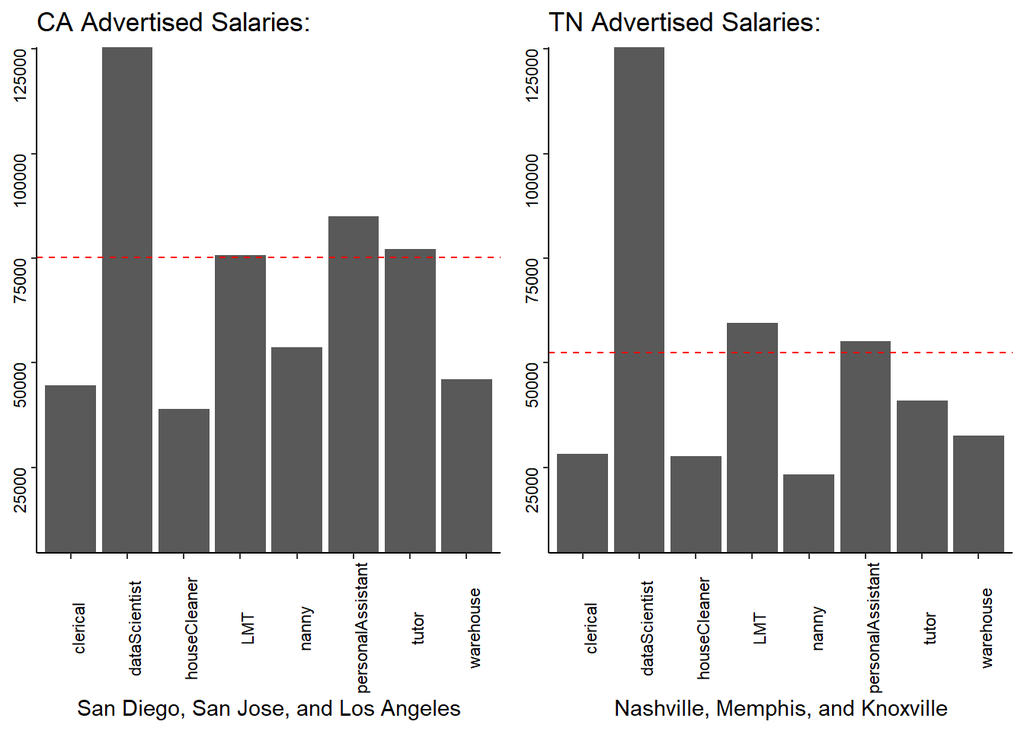

```r
grid.arrange(gg7,gg8, ncol=2)
```